# Introduction to Logranktest

19075

2020-01-02

# packages introduction

## 1.背景

生存分析是综合考虑结果和生存时间的一种统计方法，并可充分利用截尾数据所提供的不完全信息，对生存时间的分布特征进行描述，对影响生存时间的主要因素进行分析。本报告法采用Logrank test 和Permutation test 结合的方法,数据集采用survival包中的aml和lung。结果显示，使用aml数据集（n<50）进行检验，在5%显著性水平下，logrank test和Permutation test都不能拒绝零假设；使用lung数据集（n>200）进行检验，在5%显著性水平下，logrank test 和Permutation test均显著拒绝零假设。

## 2.简介

aml(boot)数据包含两组急性髓系白血病(aml)患者缓解时间的估计。一组接受维持化疗治疗，另一组不接受。自行编写了一个R函数，使用大样本近似和permytation test进行logrank test。我们采用四种不同权重的logrank test统计量检验两组患者的生存期分布是否相等。之后，使用编写的函数来测试这两个组在aml(boot)数据中的生存分布是否相等。

## 3.检验方法

### 3.1 Logrank Test

Generalized Wilcoxon: $Z_{2}=\frac{\sum_{j=1}^{n} w_{j}\left(O_{j}-E_{j}\right)}{\sqrt{\sum_{j=1}^{n} w_{j}^{2} V_{j}^{2}}} \quad w_{j}=Y_{j}$

Tarone and Ware: $Z_{3}=\frac{\sum_{j=1}^{n} w_{j}\left(O_{j}-E_{j}\right)}{\sqrt{\sum_{j=1}^{n} w_{j}^{2} V_{j}^{2}}} \quad w_{j}=\sqrt{Y_{j}}$

Mantel-Haenszel logrank相当于各时间点权重都为1,更适用于生存分布比较均匀的情形。

Generalized Wilcoxon各时间点权重为$Y_{j}$,为该时刻观测总人数,更适用于早期出现大面积死亡的分布情形。 Tarone and Ware以$\sqrt{Y_{j}}$为权重,效果介于前两者之间。

此外，综合考虑两种样本,还可以使用 Cox-Mantel Logrank $: Z_{4}=\frac{\sum_{j=1}^{n}\left(O_{1} j-E_{1} j\right)^{2}}{\sum_{j=1}^{n} E_{1} j}+\frac{\sum_{j=1}^{n}\left(O_{2} j-E_{2} j\right)^{2}}{\sum_{j=1}^{n} E_{2} j}$

同样的，基于新补充的三个统计量,我们可以计算新的p值.

### 3.2 Permutation Test

置换检验，是一种基于大量计算、利用样本数据的随机排列，进行统计推断的方法。因其对总体分布自由，特别适合用于总体分布未知的小样本数据，以及一些常规方法难以使用的假设检验情况。其计算的基本步骤为： （1） 假设样本本间分布相同

（2） 计算这两个样本相关统计量Z

（3） 将两组样本合并,按原先的数目随机分组,对新分的组计算相关统计量Z’

（4） 重复步骤(3)B次.得到$p=\frac{1+\#\left\{Z^{\prime}>Z\right\}}{B+1}$

我们使用3.1的Mantel-Haenszel Logrank,Generalized Wilcoxon,Tarone and Ware以及Cox-Mantel Logrank四个统计量作为相关统计量，计算p值.

## 4.Print method And Menu

我们给函数surlogrank()的输出编写了S3 method,命名为logrankmethod

```r
logrankmethod <- function(x) UseMethod("logrankmethod")
logrankmethod.default <- function(x) "Unknown class"
logrankmethod.logrank <- function(x){
  xx=as.numeric(as.character(x[1:12]))
  if(as.logical(x[13])){
    cat("     permutation TEST\n")
    cat("\n")
    cat("Mantel-Haenszel logrank\n")
    cat("——————————————————————————————————\n")
    cat("Test Statistic:")
    cat(" ",xx[1],"\n")
    cat("       p value:")
    cat(" ",xx[9],"\n")
    cat("\n")
    cat("Cox-Mantel Logrank\n")
    cat("——————————————————————————————————\n")
    cat("Test Statistic:")
    cat(" ",xx[3],"\n")
    cat("       p value:")
    cat(" ",xx[10],"\n")
    cat("\n")
    cat("Generalized Wilcoxon\n")
    cat("——————————————————————————————————\n")
    cat("Test Statistic:")
    cat(" ",xx[5],"\n")
    cat("       p value:")
    cat(" ",xx[11],"\n")
    cat("\n")
    cat("Tarone and Ware\n")
    cat("——————————————————————————————————\n")
    cat("Test Statistic:")
    cat(" ",xx[7],"\n")
    cat("       p value:")
    cat(" ",xx[12],"\n")
  }else{
    cat("     LOGRANK TEST\n")
    cat("\n")
    cat("Mantel-Haenszel logrank\n")
    cat("——————————————————————————————————\n")
    cat("Test Statistic:")
    cat(" ",xx[1],"\n")
    cat("       p value:")
    cat(" ",xx[2],"\n")
    cat("\n")
    cat("Cox-Mantel Logrank\n")
    cat("——————————————————————————————————\n")
    cat("Test Statistic:")
    cat(" ",xx[3],"\n")
    cat("       p value:")
    cat(" ",xx[4],"\n")
    cat("\n")
    cat("Generalized Wilcoxon\n")
    cat("——————————————————————————————————\n")
    cat("Test Statistic:")
    cat(" ",xx[5],"\n")
    cat("       p value:")
    cat(" ",xx[6],"\n")
    cat("\n")
    cat("Tarone and Ware\n")
    cat("——————————————————————————————————\n")
    cat("Test Statistic:")
    cat(" ",xx[7],"\n")
    cat("       p value:")
    cat(" ",xx[8],"\n")
  }
}
```

## 5.数据测试

我们选择小样本和大样本数据分别进行测试.

### 5.1 小样本

boot包中aml数据集包含两组急性髓系白血病患者缓解时间的估计。一组接受维持化疗治疗，另一组不接受。

```r
data(aml)
library(SC19075)
library(boot)
z=surlogrank(aml$time,aml$cens,aml$group,permutation = TRUE)
logrankmethod(z)
```

```
##      permutation TEST
##
## Mantel-Haenszel logrank
## ——————————————————————————————————
## Test Statistic:  3.396389
##        p value:  0.065
##
## Cox-Mantel Logrank
## ——————————————————————————————————
## Test Statistic:  3.135172
##        p value:  0.058
##
## Generalized Wilcoxon
## ——————————————————————————————————
## Test Statistic:  2.723312
##        p value:  0.085
##
## Tarone and Ware
## ——————————————————————————————————
## Test Statistic:  2.981604
##        p value:  0.076
```

```r
library(SC19075)
library(boot)
z=surlogrank(aml$time,aml$cens,aml$group,permutation = FALSE)
logrankmethod(z)
```

```
##      LOGRANK TEST
##
## Mantel-Haenszel logrank
## ——————————————————————————————————
## Test Statistic:  3.396389
##        p value:  0.06533932
##
## Cox-Mantel Logrank
## ——————————————————————————————————
## Test Statistic:  3.135172
##        p value:  0.07662031
##
## Generalized Wilcoxon
## ——————————————————————————————————
## Test Statistic:  2.723312
##        p value:  0.09889265
##
## Tarone and Ware
## ——————————————————————————————————
## Test Statistic:  2.981604
##        p value:  0.08421579
```

此外我们调用R的survival包自带的survdiff()函数,进一步验证

```r
library(survival)
survdiff(Surv(time,status)~x,data=aml)
```

```
## Call:
## survdiff(formula = Surv(time, status) ~ x, data = aml)
##
##                  N Observed Expected (O-E)^2/E (O-E)^2/V
## x=Maintained    11        7    10.69      1.27       3.4
## x=Nonmaintained 12       11     7.31      1.86       3.4
##
##  Chisq= 3.4  on 1 degrees of freedom, p= 0.07
```

基于以上检验,在置信水平为5%时，我们不能拒绝原假设,即服药可能有效,可能无效。

### 5.2 大样本

我们使用survival包内lung数据集包含肺癌晚期的生存数据,按性别分为两组.

```r
library(SC19075)
library(survival)
data(lung)
z=surlogrank(lung$time,lung$status-1,lung$sex,permutation = FALSE)
logrankmethod(z)
```

```
##      LOGRANK TEST
##
## Mantel-Haenszel logrank
## ——————————————————————————————————
## Test Statistic:  10.32674
##        p value:  0.001311165
##
## Cox-Mantel Logrank
## ——————————————————————————————————
## Test Statistic:  10.23077
##        p value:  0.001381167
##
## Generalized Wilcoxon
## ——————————————————————————————————
## Test Statistic:  12.47214
##        p value:  0.0004130676
##
## Tarone and Ware
## ——————————————————————————————————
## Test Statistic:  12.45554
##        p value:  0.000416753
```

```r
library(SC19075)
library(survival)
z=surlogrank(lung$time,lung$status-1,lung$sex,permutation = TRUE)
logrankmethod(z)
```

```
##      permutation TEST
##
## Mantel-Haenszel logrank
## ——————————————————————————————————
## Test Statistic:  10.32674
##        p value:  0.002
##
## Cox-Mantel Logrank
## ——————————————————————————————————
## Test Statistic:  10.23077
##        p value:  0.002
##
## Generalized Wilcoxon
## ——————————————————————————————————
## Test Statistic:  12.47214
##        p value:  0.001
##
## Tarone and Ware
## ——————————————————————————————————
## Test Statistic:  12.45554
##        p value:  0.001
```

调用R内置函数survdiff()

```r
library(survival)
survdiff(Surv(time,status)~sex,data=lung)
```

```
## Call:
## survdiff(formula = Surv(time, status) ~ sex, data = lung)
##
##         N Observed Expected (O-E)^2/E (O-E)^2/V
## sex=1 138      112     91.6      4.55      10.3
## sex=2  90       53     73.4      5.68      10.3
##
##  Chisq= 10.3  on 1 degrees of freedom, p= 0.001
```

## 6.函数用法细节展示

```r
#time      实验观察时间点
#status    0-1变量，患者处于的状态（1：fail or 0：at risk）
#group     实验分组
#permutation TRUE只用permutation检验,FALSE不用permutation检验
#该函数仅仅用于检验两样本的logrank检验
surlogrank <- function(time,status,group,permutation){
  err=paraerr(time, status, group)                    #检验函数paraerr
  if(err==1){
    return("参数输入有误。")
  }
  testgroup=data.frame(time,status,group)
  label=names(table(testgroup$group))                 #组号
  testgroup2=testgroup[testgroup$group==label[2],]    #第二个组
  testgroup1=testgroup[testgroup$group==label[1],]    #第一个组
  J2=length(table(testgroup2$time))                   #第二个组不同的观察时间点
  testgoup_status1=testgroup[testgroup$status==1,]    #cens=1的实验数据
  time=as.numeric(names(table(testgoup_status1$time)))#testgoup_status1中不同的时间观察点
  J=length(time)                                      #不同的时间观察点的个数
  ##2.二组死的各个观察时间点的死亡人数   O
  O=vector(mode="numeric",length=J)
  O2=vector(mode="numeric",length=J2)
  time_group2=as.numeric(names(table(testgroup2$time)))
  for(i in 1:J2){
    O2[i]=sum(testgroup2[testgroup2$time==time_group2[i],]$status)
  }
  for(i in 1:J2){
    O[which(time==time_group2[i])]=O2[i]
  }
  ##3.整组在j时间点死亡的人数   d
  d=vector(length=J)
  for(i in 1:J){
    d[i]=sum(testgroup[testgroup$time==time[i],]$status)
  }
  ##4.二组在j时间点剩下的人数   Y2
  population_2=nrow(testgroup2)
  Y2=vector(length=J)
  Y2[1]=population_2
  for(i in 2:J){
    Y2[i]=population_2-nrow(testgroup2[testgroup2$time<time[i],])
  }
  ##5.整组在j时间点剩下的人数
  population=nrow(testgroup)
  Y=vector(length=J)
  for(i in 1:J){
    Y[i]=population-nrow(testgroup[testgroup$time<time[i],])
  }
  ##6.一组在j时间点剩下的人数
  Y1=vector(length=J)
  Y1=Y-Y2
  ##7.expected number of failures
  E=vector(length=J)
  for(j in 1:J){
    E[j]=d[j]*Y2[j]/Y[j]
  }
  ##8.variance of the observed number of failures
  V=vector(length=J)
  for(j in 1:J)
    V[j]=(Y1[j]*Y2[j]*d[j]*(Y[j]-d[j]))/((Y[j])^2*(Y[j]-1))
  ##9.Mantel-Haenszel Logrank Test Z1统计量和p值
  Z=sum(O-E)/sqrt(sum(V))
  Z1=Z^2
  p_value1=1-pchisq(q=Z1,df=1)
  ##10.Cox-Mantel Logrank Test Z2统计量和p值
  E1=vector(length=J)
  for(j in 1:J){
    E1[j]=d[j]*Y1[j]/Y[j]
  }
  d2=O
  d1=d-d2
  E2=vector(length=J)
  for(j in 1:J){
    E2[j]=d[j]*Y2[j]/Y[j]
  }
  Z2=(sum(d1-E1))^2/(sum(E1))+(sum(d2-E2))^2/(sum(E2))
  p_value2=1-pchisq(q=Z2,df=1)
  ##11.Generalized Wilcoxon Z3统计量和和p值
  Z3=(t(Y) %*%(O-E))^2/((t(Y)^2)%*%V)
  p_value3=1-pchisq(q=Z3,df=1)
  ##12.Tarone and Ware  Z4统计量和p值
  Z4=(t(sqrt(Y)) %*%(O-E))^2/(t(Y)%*%V)
  p_value4=1-pchisq(q=Z4,df=1)
  ##13.permutation test p值
  n1=nrow(testgroup1)       #一组人数
  n2=nrow(testgroup2)       #二组人数
  S_obs=mean(testgroup2$status)-mean(testgroup1$status)
  S_obs=abs(S_obs)
  nsims=1000       #循环次数
  sim_re=matrix(0,nrow=nsims,ncol=4)    #循环结果
  for(i in 1:nsims){
    tmp=sample(c(rep(1,n1),rep(2,n2)))
    sim_re[i,]=as.numeric(permut(testgroup$time, testgroup$status, tmp))
  }
  p_value5=mean(Z1<abs(sim_re[,1]))
  p_value6=mean(Z2<abs(sim_re[,2]))
  p_value7=mean(as.numeric(Z3)<abs(sim_re[,3]))
  p_value8=mean(as.numeric(Z4)<abs(sim_re[,4]))
  ##14.函数输出
  logrankoutput=structure(list(Z1,p_value1,Z2,p_value2,Z3,p_value3,Z4,p_value4,p_value5,p_value6,p_value7,p_value8,permutation),class="logrank")
  return(logrankoutput)
}
```

## 参考文献

- Peto, Julian Peto.Asymptotically Efficient Rank Invariant Test Produres.In:Journal of Rayal Statistical Society.Series A(General),Vol.135,NO.2(1972),pp.185-207
- E. L. Kaplan and Paul Meier.Nonparametric Estimation from Incomplete Observations.Journal of the American Statistical Association, Vol. 53, No.282 (Jun., 1958), pp.457-481
- Maria L. Rizzo.Statistical Computing with R.Chapman & Hall/CRC:2008

# Homework

## HW1:2019-9-20

- Go through “R for Beginners” if you are not familiar with R programming.
- Use knitr to produce at least 3 examples (texts, figures, tables).

###Figures

We take some examples to generate figures which use plot,hist and so an,and we adjust the parameters in par .

#### 1. *Gamma Distribution*

- p for “probability”, the cumulative distribution function (c. d. f.) q for “quantile”, the inverse c. d. f. we take gamma distribution for example

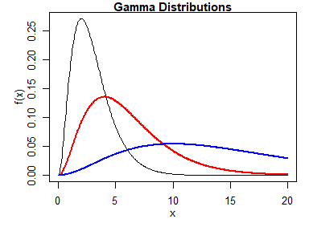

```r
par(mar = c(4, 4, 1, 1), mgp = c(2, 1, 0),cex=0.8)
this.range <- seq(0, 20, .05)
plot (this.range, dgamma(this.range,shape = 3), ty="l", main="Gamma Distributions",
      xlab="x", ylab="f(x)")
lines (this.range, dgamma(this.range,shape = 3, rate=0.5), col="red",lwd=2)
lines (this.range, dgamma(this.range,shape = 3, rate=0.2), col="blue",lwd=2)
```

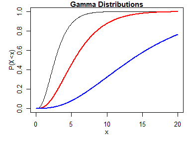

```r
par(mar = c(4, 4, 1, 1), mgp = c(2, 1, 0), cex = 0.8)
this.range <- seq(0, 20, .05)
plot (this.range, pgamma(this.range,shape = 3), ty="l", main="Gamma Distributions",
      xlab="x", ylab="P(X<x)")
lines (this.range, pgamma(this.range,shape = 3, rate=0.5), col="red",lwd=2)
lines (this.range, pgamma(this.range,shape = 3, rate=0.2), col="blue",lwd=2)
```

#### 2. *Linear Fitting*

- We examine the relationship between speed and stopping distance using a linear regression model: $Y = \beta_0 + \beta_1 x + \epsilon$.

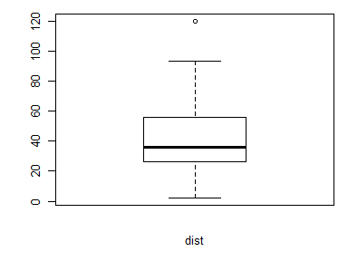

```r
par(mar = c(4, 4, 1, 1), mgp = c(2, 1, 0), cex = 0.8)
boxplot(cars$dist, xlab = "dist")
```

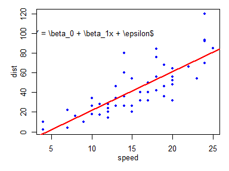

```r
plot(cars, pch = 20, col = 'blue')
library(latex2exp)
text(10, 100, '$Y = \\beta_0 + \\beta_1x + \\epsilon$')
fit <- lm(dist ~ speed, data = cars)
abline(fit,lwd = 2,col='red')
```

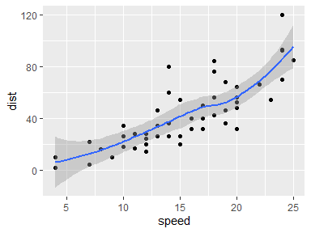

```r
library(ggplot2)
qplot(speed, dist, data = cars) + geom_smooth()
```

#### 3. *Pie Charts*

- Pie charts represent data, which makes it easier to comprehend the information quickly instead of browsing through a lot of statistical data.

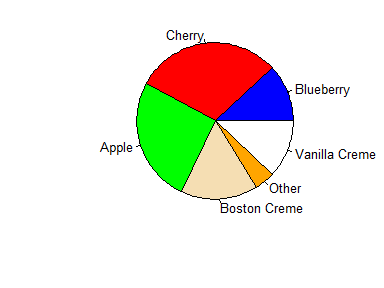

```r
par(mar = c(4, 4, 1, 1), mgp = c(2, 1, 0),cex=0.8)
pie.sales = c(0.12, 0.30, 0.26, 0.16, 0.04, 0.12)
names(pie.sales) = c("Blueberry", "Cherry", "Apple", "Boston Creme",
                     "Other", "Vanilla Creme")
pie(pie.sales, col = c("blue", "red", "green", "wheat", "orange", "white"))
```

### Tables

#### 1. *Kable and its parameters*

- kable_styling can adjust the table’s look,like striped(the line and the next look different),hover(in the middle of the space),condensed(just as it described),responsive(different when resize the window)…

```r
library(knitr)
library(kableExtra)
dt <- mtcars[1:5, 1:6]
kable(dt) %>%
  kable_styling(bootstrap_options = c("striped", "hover","condensed","responsive"))
```

|  | mpg | cyl | disp | hp | drat | wt |
| --- | --- | --- | --- | --- | --- | --- |
| Mazda RX4 | 21.0 | 6 | 160 | 110 | 3.90 | 2.620 |
| Mazda RX4 Wag | 21.0 | 6 | 160 | 110 | 3.90 | 2.875 |
| Datsun 710 | 22.8 | 4 | 108 | 93 | 3.85 | 2.320 |
| Hornet 4 Drive | 21.4 | 6 | 258 | 110 | 3.08 | 3.215 |
| Hornet Sportabout | 18.7 | 8 | 360 | 175 | 3.15 | 3.440 |

#### 2. *Column_spec and Row_spec*

- make the row or columns specialized by color or bold chracters

```r
text_tbl <- data.frame(
  Items = c('mpg','cyl','disp','hp','drat','wt'),
  meanings = c(
    "Miles/(US) gallon","Number of cylinders", "Displacement (cu.in.)","Gross horsepower","Rear axle ratio","Weight (1000 lbs)"
  )
)

kable(text_tbl) %>%
  kable_styling(full_width = F) %>%
  column_spec(1, bold = T, border_right = T) %>%
  column_spec(2, width = "30em", background = "yellow")
```

| Items | meanings |
| --- | --- |
| mpg | Miles/(US) gallon |
| cyl | Number of cylinders |
| disp | Displacement (cu.in.) |
| hp | Gross horsepower |
| drat | Rear axle ratio |
| wt | Weight (1000 lbs) |

```r
kable(dt) %>%
  kable_styling("striped", full_width = F) %>%
  column_spec(5:7, bold = T) %>%
  row_spec(3:5, bold = T, color = "white", background = "#D7261E")
```

|  | mpg | cyl | disp | hp | drat | wt |
| --- | --- | --- | --- | --- | --- | --- |
| Mazda RX4 | 21.0 | 6 | 160 | 110 | 3.90 | 2.620 |
| Mazda RX4 Wag | 21.0 | 6 | 160 | 110 | 3.90 | 2.875 |
| Datsun 710 | 22.8 | 4 | 108 | 93 | 3.85 | 2.320 |
| Hornet 4 Drive | 21.4 | 6 | 258 | 110 | 3.08 | 3.215 |
| Hornet Sportabout | 18.7 | 8 | 360 | 175 | 3.15 | 3.440 |

#### 3. *Specilized conditionally*

- conditioning on the contents of table to specialize it.ifelse().also need to search some code represnting the colors.

```r
library(dplyr)
mtcars[1:10, 1:2] %>%
  mutate(
    car = row.names(.),
    mpg = cell_spec(mpg, "html", color = ifelse(mpg > 20, "red", "green")),
    cyl = cell_spec(cyl, "html", color = "white", align = "r", angle = 30,
                    background = factor(cyl, c(4, 6, 8),
                                        c("#666666", "#999999", "#BBBBBB")))
  ) %>%
  select(car, mpg, cyl) %>%
  kable(format = "html", escape = F) %>%
  kable_styling("striped", full_width = F)
```

| car | mpg | cyl |
| --- | --- | --- |
| Mazda RX4 | 21 | 6 |
| Mazda RX4 Wag | 21 | 6 |
| Datsun 710 | 22.8 | 4 |
| Hornet 4 Drive | 21.4 | 6 |
| Hornet Sportabout | 18.7 | 8 |
| Valiant | 18.1 | 6 |
| Duster 360 | 14.3 | 8 |
| Merc 240D | 24.4 | 4 |
| Merc 230 | 22.8 | 4 |
| Merc 280 | 19.2 | 6 |

### Text

#### 1. *Basic order*

- use the package format R

```r
library(formatR)
gpl = readLines(file.path(R.home(), "COPYING"))
head(gpl)
```

```
## [1] "\t\t    GNU GENERAL PUBLIC LICENSE"
## [2] "\t\t       Version 2, June 1991"
## [3] ""
## [4] " Copyright (C) 1989, 1991 Free Software Foundation, Inc."
## [5] "                       51 Franklin St, Fifth Floor, Boston, MA  02110-1301  USA"
## [6] " Everyone is permitted to copy and distribute verbatim copies"
```

#### 2. *Text Specification*

- make the size and color of the texts vary gradually

```r
library(dplyr)
sometext <- strsplit(paste0(
  "You can even try to make some crazy things like this paragraph. ",
  "It may seem like a useless feature right now but it's so cool ",
  "and nobody can resist. ;)"
), " ")[[1]]
text_formatted <- paste(
  text_spec(sometext, color = spec_color(1:length(sometext), end = 0.9),
            font_size = spec_font_size(1:length(sometext), begin = 5, end = 20)),
  collapse = " ")
```

You can even try to make some crazy things like this paragraph. It may seem like a useless feature right now but it’s so cool and nobody can resist. ;)

## HW2:2019-9-29

### Question

**3.4, 3.11, 3.18**

### Answer

```r
Rayleigh<-function(a){
  set.seed(123456)
  n <- 10000
k <- 0 # counter for acception
j <- 0 # iterations
x <- numeric(n) # initiation
while(k < n){
  u <- runif(1)
  j <- j + 1
  y <- rgamma(1,shape = 2,rate=1) # random variate from g
  if(exp(y-y^2/(2*a^2)-a^2/2)>=u){
    k <- k + 1
    x[k] <- y }
}
return(x)}
```

*a=1*

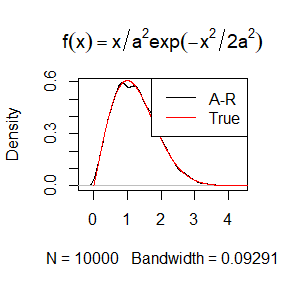

```r
a=1
x1<-Rayleigh(1)
plot(density(x1), main = bquote(f(x)==x/a^2*exp(-x^2/2*a^2)))
this.range <- seq(0, 5, 0.01)
f <- function(x) x/(a^2)*exp(-x^2/(2*a^2))
lines(this.range,f(this.range), col="red")
legend("topright", legend = c("A-R", "True"), col=c("black", "red"), lty=1)
```

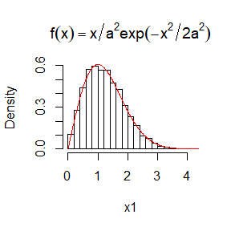

```r
hist(x1, probability = TRUE, main=bquote(f(x)==x/a^2*exp(-x^2/2*a^2)))
lines(this.range, f(this.range), col="red")
```

*a=2*

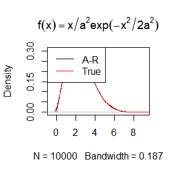

```r
a=2
x2<-Rayleigh(2)
plot(density(x2), main = bquote(f(x)==x/a^2*exp(-x^2/2*a^2)))
this.range <- seq(0, 10, 0.01)
f <- function(x) x/(a^2)*exp(-x^2/(2*a^2))
lines(this.range,f(this.range), col="red")
legend("topleft", legend = c("A-R", "True"), col=c("black", "red"), lty=1)
```

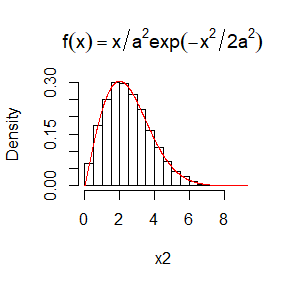

```r
hist(x2, probability = TRUE, main=bquote(f(x)==x/a^2*exp(-x^2/2*a^2)))
lines(this.range, f(this.range), col="red")
```

*a=3*

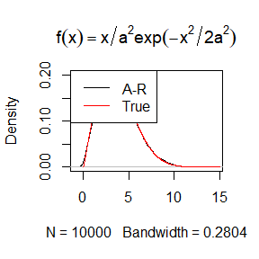

```r
a=3
x3<-Rayleigh(3)
plot(density(x3), main = bquote(f(x)==x/a^2*exp(-x^2/2*a^2)))
this.range <- seq(0, 15, 0.01)
f <- function(x) x/(a^2)*exp(-x^2/(2*a^2))
lines(this.range,f(this.range), col="red")
legend("topleft", legend = c("A-R", "True"), col=c("black", "red"), lty=1)
```

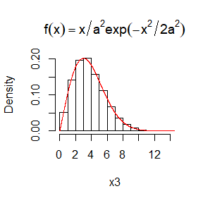

```r
hist(x3, probability = TRUE, main=bquote(f(x)==x/a^2*exp(-x^2/2*a^2)))
lines(this.range, f(this.range), col="red")
```

#### 3.11

- we repeat the histogram of different p1,make a conjecture that when pi is from 0.4 to o.6,that will produce bimodal mixtures.

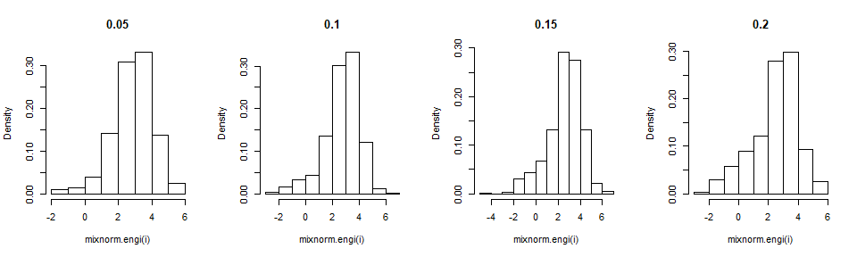

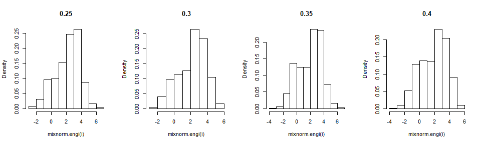

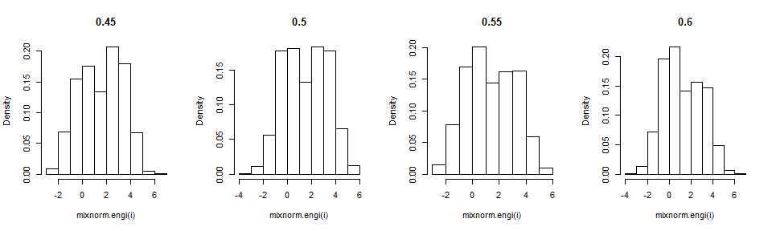

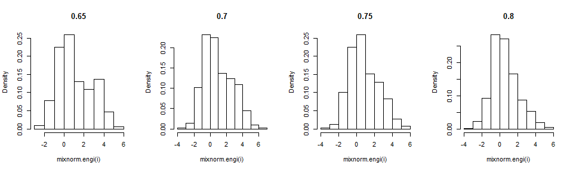

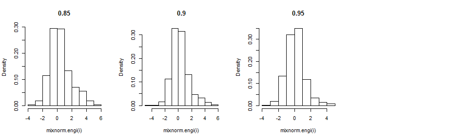

```r
mixnorm.engi<-function(p1){
  n<-1000
y1<-rnorm(n,0,1)
y2<-rnorm(n,3,1)
r<-sample(c(0,1),n,prob = c(p1,1-p1),replace = TRUE)
z<-r*y2+(1-r)*y1
return(z)
}
par(mfcol=c(1,4))
i=0.05
while(i<1){
hist(mixnorm.engi(i),probability = TRUE,main = i)
  i=i+0.05
}
```

#### 3.18

-the fuction that can produce random sample of Wishart

```r
Wishart.eigen<-function(sigma,n){
  set.seed(123456)
  T<-matrix(rnorm(n*n,0,1),n,n)       #generate a n*n matrix of normal distribution N(0,1)
  i=1
  num<-c()
  while (i<=n) {
    num[i]<-sqrt(rchisq(1,n-i+1,ncp = 0))
  }
  diag(T)<-num       #generate the diagram of the matrix, which conforms to the sprt of chi-square distribution,the parameter is n-i-1 of the ith value
  T[upper.tri(T)]<-0       #turn the upper of the matrix into 0
  A=T%*%t(T)       #then we get A whose sigma is In
  csigma<-chol(sigma)
  return(csigma%*%A%*%t(csigma))       #for the genral situation,we use Choleski decomposition to get the arbitrary sigam
}
```

## HW3:2019-10-11

### Question 1

- **5.1**计算$\int_{0}^{\pi/3}\ sint dt$的蒙特卡罗估计并比较估计值和积分精确值。

### Answer 1

- use MC method to get it

```r
set.seed(12345)
m <- 1e4
x <- runif(m, min=0, max=pi/3)
theta.hat <- mean(sin(x)) * (3/pi)
print(c(theta.hat,cos(0) - cos(3/pi)))
```

```
## [1] 0.4567774 0.4223338
```

### Question 2

- **5.10**使用对偶变量蒙特卡罗积分法来估计
  $$\int_{0}^{1} \frac{e^{-x}}{1+x^{2}}dx$$
  并用未缩减方差百分比的形式给出近似方差缩减。

### Answer 2

- we use three methods to compute it.
- **a. Antithetic variables**

```r
set.seed(12345)
m <- 1e4
u <- runif(m/2, min=0, max=1)
v=1-u
u<-c(u,v)
g<-exp(-u)/(1+u^2)
MC1 <-mean(g)
MC1
```

```
## [1] 0.5244769
```

```r
var1<-var(g)
```

- b.Importance sampling(
  $$(1-x) /(1+x \wedge 2)$$
  )

```r
set.seed(12345)
m <- 1e4
u <- runif(m, min=0, max=1)
f <- function(u)(1-u)/(1+u^2)
g <- function(u)exp(-u)/(1+u^2)
B <- f(u)
A <- g(u)
covAB <- cor(A, B)
cstar <- -cov(A,B) / var(B)
T <- g(u) + cstar * (f(u) - pi/4+log(2)/2)
MC2<-mean(T)
MC2
```

```
## [1] 0.5247172
```

```r
var2<-var(T)
```

- c.Importance sampling(
  $$\exp (-u) /(1+u \wedge 2)$$
  )

```r
set.seed(12345)
m <- 1e4
u <- rexp(m,rate = 1)
f <- function(u)exp(-u)/(1-exp(-1))
g <- function(u)exp(-u)/(1+u^2)*(u>0)*(u<1)
B <- f(u)
A <- g(u)
MC3<-mean(A/B)/(1-exp(-1))
MC3
```

```
## [1] 0.5230745
```

```r
var3<-var(A/B)/m
```

```r
library(knitr)
library(kableExtra)
dt<-data.frame('classes'=c('a','b','c'),'results'=c(MC1,MC2,MC3),variance=c(var1,var2,var3))
kable(dt) %>%
  kable_styling(full_width = F) %>%
  column_spec(1) %>%
  column_spec(2, width = "10em", background = "yellow")%>%
  column_spec(3, width = "10em", background = "yellow")
```

| classes | results | variance |
| --- | --- | --- |
| a | 0.5244769 | 0.0595255 |
| b | 0.5247172 | 0.0000688 |
| c | 0.5230745 | 0.0000070 |

### Question 3

- **5.15**得到例5.13中的分层重要估计并和例5.10中的结果进行比较:考虑[0,1]区间上被积函数$g(x)=\frac{e^{-x}}{1+x^2}$,选取重要函数$f_{3}=\frac{e^{-x}}{1-e^{-1}},0<x<1$,其对应的分布函数为$F_{3}=\frac{1-e^{-x}}{1-e^{-1}},0<x<1$。现在把区间（0,1）分成5个子区间$(\alpha_{j},\alpha_{j+1}),j=0,1,\dots,4,\alpha_{j}=F_{3}^{-1}(j/5)$。在第j个子区间上根据密度
  $$\frac{5 e^{-x}}{1-e^{-1}}, \quad \alpha_{j}<x<\alpha_{j+1}$$
  生成随机变量。

### Answer 3

```r
q<-seq(0,1,by=0.2)
p<- -log(1-(1-exp(-1))*q) ##divide into intervals
set.seed(12345)
m <- 1e4
f <- function(u)5*exp(-u)/(1-exp(-1))##conditional probability
theta<-numeric(5)
deta<-numeric(5)
for(i in 1:5){
  u <- rexp(m,rate = 1)
  g<-function(u)exp(-u)/(1+u^2)*(u>p[i])*(u<p[i+1]) ##gi(x)=g(x)when locate at the intrval
  m<-g(u)
  n<-f(u)
  a<-m/n
  deta[i]=var(a)
  theta[i]=5*mean(a)/(1-exp(-1))
}
MC4<-sum(theta)
var<-mean(deta)
c(MC4,var)
```

```
## [1] 0.52175159 0.00125233
```

## HW4:2019-10-18

### Question 1

- Suppose a 95% symmetric t-interval is applied to estimate a mean, but the sample data are non-normal. Then the probability that the confidence interval covers the mean is not necessarily equal to 0.95. Use a Monte Carlo experiment to estimate the coverage probability of the t-interval for random samples of $\chi^2(2)$ data with sample size n = 20. Compare your t-interval results with the simulation results in Example 6.4. (The t-interval should be more robust to departures from normality than the interval for variance.)

### Answer 1

Theorem. If X1, X2, …, Xn are normally distributed random variables with mean μ and variance σ2, then a (1−α)100% confidence interval for the population mean μ is:

$\bar{x} \pm t_{\alpha / 2, n-1}\left(\frac{s}{\sqrt{n}}\right)$

This interval is often referred to as the "t-interval for the mean.

```r
set.seed(123456)
alpha = 0.05
n = 20
m = 1000

UCL = numeric(m)
LCL = numeric(m)

for(i in 1:m)
{
    x = rchisq(n, 2)
    LCL[i] = mean(x) - qt(alpha / 2, df=n-1, lower.tail = FALSE)*sd(x)/sqrt(n)
    UCL[i] = mean(x) + qt(alpha / 2, df=n-1, lower.tail = FALSE)*sd(x)/sqrt(n)
}

mean(LCL < 2 & UCL > 2)
```

```
## [1] 0.933
```

compare with x = rnorm(n) + 2

```r
set.seed(123456)
alpha = 0.05
n = 20
m = 1000

UCL = numeric(m)
LCL = numeric(m)

for(i in 1:m)
{
    x = rnorm(n)+2
    LCL[i] = mean(x) - qt(alpha / 2, df=n-1, lower.tail = FALSE)*sd(x)/sqrt(n)
    UCL[i] = mean(x) + qt(alpha / 2, df=n-1, lower.tail = FALSE)*sd(x)/sqrt(n)
}

mean(LCL < 2 & UCL > 2)
```

```
## [1] 0.959
```

compare with the example in textbook

```r
set.seed(123456)
alpha = 0.05
n = 20
m = 1000

UCL = numeric(m)
for(i in 1:m)
{
  x <- rnorm(n, mean = 0, sd = 2)
  UCL[i] <- (n-1) * var(x) / qchisq(alpha, df=n-1)
}
mean(UCL>4)
```

```
## [1] 0.95
```

### Question 2

- Estimate the 0.025, 0.05, 0.95, and 0.975 quantiles of the skewness $\sqrt{b_1}$ under normality by a Monte Carlo experiment. Compute the standard error of the estimates from (2.14) using the normal approximation for the density (with exact variance formula). Compare the estimated quantiles with the quantiles of the large sample approximation $\sqrt{b_{1}} \approx N(0,6 / n)$

### Answer 2

To calculate the variance of quantile of skewness $\operatorname{Var}\left(\hat{x}_{q}\right)=\frac{q(1-q)}{n f\left(x_{q}\right)^{2}}$ f(x) is the density function of N(0,var), to calculate var,we use $\operatorname{Var}(\sqrt{b_{1}})=\frac{6(n-2)}{(n+1)(n+3)}$

```r
set.seed(123456)
m=1000
n=20
skewness<-numeric(m)
sk <- function(x) {
xbar <- mean(x)
m3 <- mean((x - xbar)^3)
m2 <- mean((x - xbar)^2)
return( m3 / m2^1.5 )
}
for(i in 1:1000){
  skewness[i]<-sk(rnorm(n))
}
q_0.025<-quantile(skewness,0.025)
q_0.05<-quantile(skewness,0.05)
q_0.95<-quantile(skewness,0.95)
q_0.975<-quantile(skewness,0.975)
qt_0.025<-qnorm(0.025,mean=0,sd=sqrt(6*(n-2)/((n+1)*(n+3))),lower.tail = TRUE)
qt_0.05<-qnorm(0.05,mean=0,sd=sqrt(6*(n-2)/((n+1)*(n+3))),lower.tail = TRUE)
qt_0.95<-qnorm(0.95,mean=0,sd=sqrt(6*(n-2)/((n+1)*(n+3))),lower.tail = TRUE)
qt_0.975<-qnorm(0.975,mean=0,sd=sqrt(6*(n-2)/((n+1)*(n+3))),lower.tail = TRUE)
var_0.025<-0.025*(1-0.025)/(n*dnorm(qt_0.025,0,sd=sqrt(6*(n-2)/((n+1)*(n+3))))^2)
var_0.05<-0.05*(1-0.05)/(n*dnorm(qt_0.05,0,sd=sqrt(6*(n-2)/((n+1)*(n+3))))^2)
var_0.95<-0.95*(1-0.95)/(n*dnorm(qt_0.95,0,sd=sqrt(6*(n-2)/((n+1)*(n+3))))^2)
var_0.975<-0.975*(1-0.975)/(n*dnorm(qt_0.975,0,sd=sqrt(6*(n-2)/((n+1)*(n+3))))^2)
```

```r
library(knitr)
library(kableExtra)
dt<-data.frame('probability'=c(0.025,0.05,0.95,0.975),'quantile from experiment'=c(q_0.025,q_0.05,q_0.95,q_0.975),'quantile from theory'=c(qt_0.025,qt_0.05,qt_0.95,qt_0.975),'variance'=c(var_0.025,var_0.05,var_0.95,var_0.975))
kable(dt) %>%
  kable_styling(full_width = F) %>%
  column_spec(1, bold = T, border_right = T) %>%
  column_spec(2, width = "10em", background = "yellow")%>%
  column_spec(3, width = "10em", background = "yellow")%>%
   column_spec(4, width = "10em", background = "yellow")%>%
   column_spec(5, width = "10em", background = "yellow")
```

|  | probability | quantile.from.experiment | quantile.from.theory | variance |
| --- | --- | --- | --- | --- |
| 2.5% | 0.025 | -0.9380048 | -0.9268008 | 0.0797803 |
| 5% | 0.050 | -0.7450294 | -0.7777958 | 0.0499255 |
| 95% | 0.950 | 0.7434059 | 0.7777958 | 0.0499255 |
| 97.5% | 0.975 | 0.9357909 | 0.9268008 | 0.0797803 |

## HW5:2019-11-1

### Question 1

- Estimate the power of the skewness test of normality against symmetric $Beta(\alpha,\alpha)$ distributions and comment on the results. Are the results different for heavy-tailed symmetric alternatives such as $t(\nu)$?

### Answer 1

Beta distribution:$p(p | \alpha, \beta)=\frac{1}{B(\alpha, \beta)} p^{\alpha-1}(1-p)^{\beta-1} \triangleq \operatorname{Beta}(p | \alpha, \beta)$

Of which,Beta fuction:$B(\alpha, \beta)=\frac{\Gamma(\alpha) \Gamma(\beta)}{\Gamma(\alpha+\beta)}$

different parameters of the beta distribution

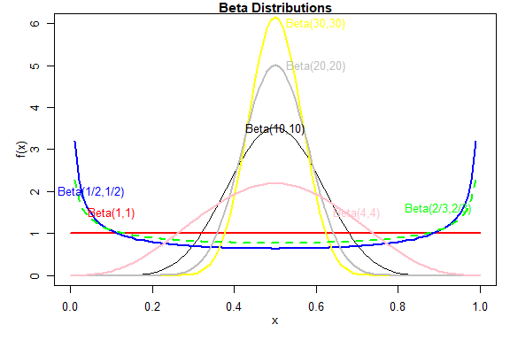

```r
par(mar = c(4, 4, 1, 1), mgp = c(2, 1, 0),cex=0.8)
this.range <- seq(0, 1, .01)
plot (this.range, dbeta(this.range,10,10), ty="l", main="Beta Distributions",
      xlab="x", ylab="f(x)",ylim=c(0,6))
lines (this.range, dbeta(this.range,1,1), col="red",lwd=2)
lines (this.range, dbeta(this.range,1/2,1/2), col="blue",lwd=2)
lines (this.range, dbeta(this.range,30,30), col="yellow",lwd=2)
lines (this.range, dbeta(this.range,20,20), col="gray",lwd=2)
lines (this.range, dbeta(this.range,4,4), col="pink",lwd=2)
lines (this.range, dbeta(this.range,2/3,2/3), col="green",lwd=2,lty=2)
text(0.5, 3.5, 'Beta(10,10)', cex = 1)
text(0.1, 1.5, 'Beta(1,1)', cex = 1,col = 'red')
text(0.05, 2, 'Beta(1/2,1/2)', cex = 1,col='blue')
text(0.6, 6, 'Beta(30,30)', cex = 1,col='yellow')
text(0.6, 5, 'Beta(20,20)', cex = 1,col='gray')
text(0.7, 1.5, 'Beta(4,4)', cex = 1,col='pink')
text(0.9, 1.6, 'Beta(2/3,2/3)', cex = 1,col='green')
```

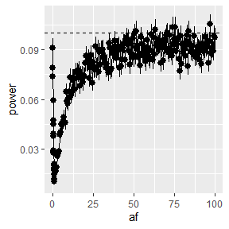

```r
sk<-function(x){#computes the sample skewness coeff
  xbar<-mean(x)
  m3<-mean((x-xbar)^3)
  m2<-mean((x-xbar)^2)
  return(m3/m2^1.5)
}
alpha<-.1
n<-30
m<-2500
af<-c(seq(0,1,.05),seq(1,100,0.5))
N<-length(af)
pwr<-numeric(N)  #critical value for the skewness test
cv<-qnorm(1-alpha/2,0,sqrt(6*(n-2)/((n+1)*(n+3))))
for(j in 1:N){
  a<-af[j]
  sktests<-numeric(m)
  for(i in 1:m){
    x<-rbeta(n,a,a)
    sktests[i]<-as.integer(abs(sk(x))>=cv)
  }
pwr[j]<-mean(sktests)

}
se<-sqrt(pwr*(1-pwr)/m)
# plot power vs af
library(ggplot2)
df<-data.frame(af=af,power=pwr,upper=pwr+se,lower=pwr-se)
ggplot(df,aes(x=af,y=power))+geom_line()+labs(x=bquote(af))+geom_hline(yintercept=.1,lty=2)+geom_pointrange(aes(ymin=lower,ymax=upper))
```

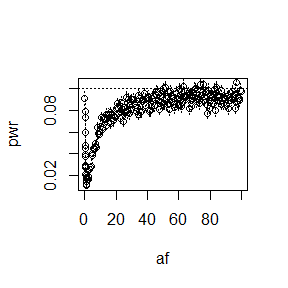

```r
plot(af, pwr, type = "b", xlab = bquote(af))
abline(h = .1, lty = 3)
lines(af, pwr+se, lty = 3)
lines(af, pwr-se, lty = 3)
```

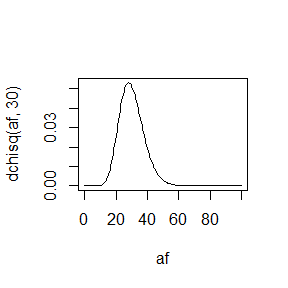

```r
plot(af,dchisq(af,30),ty='l')
```

when we change the distribution to t(v)

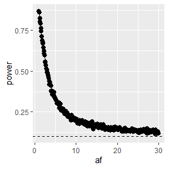

```r
alpha<-.1
n<-30
m<-2500
af<-c(seq(1,30,.1))
N<-length(af)
pwr<-numeric(N)  #critical value for the skewness test
cv<-qnorm(1-alpha/2,0,sqrt(6*(n-2)/((n+1)*(n+3))))
for(j in 1:N){
  a<-af[j]
  sktests<-numeric(m)
  for(i in 1:m){
    x<-rt(n,a)
    sktests[i]<-as.integer(abs(sk(x))>=cv)
  }
pwr[j]<-mean(sktests)

}
se<-sqrt(pwr*(1-pwr)/m)
# plot power vs af
library(ggplot2)
df<-data.frame(af=af,power=pwr,upper=pwr+se,lower=pwr-se)
ggplot(df,aes(x=af,y=power))+geom_line()+labs(x=bquote(af))+geom_hline(yintercept=.1,lty=2)+geom_pointrange(aes(ymin=lower,ymax=upper))
```

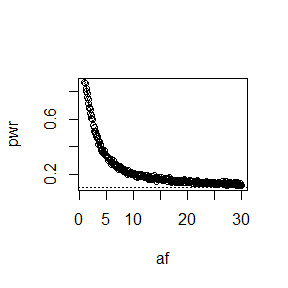

```r
plot(af, pwr, type = "b", xlab = bquote(af))
abline(h = .1, lty = 3)
lines(af, pwr+se, lty = 3)
lines(af, pwr-se, lty = 3)
```

The result is different . heavy-tailed symmetric alternatives as t(ν) ,its power of the skewness is also heavy-tailed symmetric

### Question 2

- Use Monte Carlo simulation to investigate whether the empirical Type I error rate of the t-test is approximately equal to the nominal significance level $alpha$, when the sampled population is non-normal. The t-test is robust to mild departures from normality. Discuss the simulation results for the cases where the sampled population is (i) $\chi^2(1)$, (ii) Uniform(0,2), and (iii) Exponential(rate=1). In each case, test$H_{0}: \mu=\mu_{0}$ vs $H_{1}: \mu \neq \mu_{0}$, where $\mu_{0}$ is the mean of $\chi^2(1)$, Uniform(0,2), and Exponential(1), respectively.

### Answer 2

Of course if X isn’t normally distributed, even if the type 1 error rate for the t-test assuming normality is close to 5%, the test will not be optimally powerful. That is, there will exist alternative tests of the null hypothesis which have greater power to detect alternative hypotheses.Let’s do the magic.

First,we set the sample size 10.

```r
library(knitr)
library(kableExtra)
set.seed(123456)
p.hat<-numeric(3)
se.hat<-numeric(3)
n <- 10
alpha <- .05
m <- 10000#number of replicates
p <- numeric(m) #storage for p-values
for (j in 1:m) {
  x <- rchisq(n, 1)
  ttest <- t.test(x, mu =1)
  p[j] <- ttest$p.value }
p.hat[1] <- mean(p < alpha)
se.hat[1] <- sqrt(p.hat * (1 - p.hat) / m)
for (j in 1:m) {
  x <- rexp(n, 1)
  ttest <- t.test(x, mu =1)
  p[j] <- ttest$p.value }
p.hat[2] <- mean(p < alpha)
se.hat[2] <- sqrt(p.hat * (1 - p.hat) / m)
for (j in 1:m) {
  x <- runif(n, min=0,max=2)
  ttest <- t.test(x, mu =1)
  p[j] <- ttest$p.value }
p.hat[3] <- mean(p < alpha)
se.hat[3] <- sqrt(p.hat * (1 - p.hat) / m)
df<-data.frame('Distribution'=c('chisquare','exponential','uniform'),'Type I error rate'=p.hat,'standard error of the estimate'=se.hat)
kable(df,caption = "n=10") %>%
  kable_styling("striped",full_width = F) %>%
  column_spec(1, bold = T, border_right = T) %>%
  column_spec(2, width = "20em")%>%
  column_spec(3, width = "20em")
```

n=10

| Distribution | Type.I.error.rate | standard.error.of.the.estimate |
| --- | --- | --- |
| chisquare | 0.1347 | 0.003414 |
| exponential | 0.0972 | 0.003414 |
| uniform | 0.0547 | 0.003414 |

we use the same code to run when the sample size is 50,500.

n=50

| Distribution | Type.I.error.rate | standard.error.of.the.estimate |
| --- | --- | --- |
| chisquare | 0.0834 | 0.0027649 |
| exponential | 0.0663 | 0.0027649 |
| uniform | 0.0492 | 0.0027649 |

n=500

| Distribution | Type.I.error.rate | standard.error.of.the.estimate |
| --- | --- | --- |
| chisquare | 0.0583 | 0.0023431 |
| exponential | 0.0515 | 0.0023431 |
| uniform | 0.0507 | 0.0023431 |

we were to find that our data looked non-normal. In particular, we would worry that the t-test will not perform as it should - i.e. that if the null hypothesis is true, it will falsely reject the null 5% of the time (I’m assuming we are using the usual significance level).

In fact, as the sample size in the two groups gets large, the t-test is valid (i.e. the type 1 error rate is controlled at 5%) even when X doesn’t follow a normal distribution. I think the most direct route to seeing why this is so, is to recall that the t-test is based on the groups means ￼ Because of the **central limit theorem**, the distribution of these, in repeated sampling, converges to a normal distribution, irrespective of the distribution of X in the population. Also, the estimator that the t-test uses for the standard error of the sample means is consistent irrespective of the distribution of X, and so this too is unaffected by normality. As a consequence, the test statistic continues to follow a distribution, under the null hypothesis, when the sample size tends to infinity.

What does this mean in practice? Provided our sample size isn’t too small, we shouldn’t be overly concerned if our data appear to violate the normal assumption. Also, for the same reasons, the 95% confidence interval for the difference in group means will have correct coverage, even when X is not normal (again, when the sample size is sufficiently large). Of course, for small samples, or highly skewed distributions, the above asymptotic result may not give a very good approximation, and so the type 1 error rate may deviate from the nominal 5% level.

1. the corresponding hypothesis test problem

First, we define two powers by:

The power of test method 1 = P(reject the null hypothesis in the test 1) = $P_{1}$,

The power of test method 2 = P(reject the null hypothesis in the test 2) = $P_{2}$.

And the corresponding hypothesis test problem is
$$H_{0}:P_{1} = P_{2}\longleftrightarrow H_{1}:P_{1} \neq P_{2}$$

2. the test we should use: Since the data we can get is paired nominal data, we should use **McNemar test**
3. the extra information we need

We obtain the powers from the particular simulations with 10000 experiments, consider the result(whether reject null hypothesis or not) from the two methods for every single experiment, we can show it in a contigency table.

|  | Test2 reject | Test2 accpet | row sum |
| --- | --- | --- | --- |
| Test1 reject | a | b | a + b |
| Test1 accpet | c | d | c + d |
| column sum | a + c | b + d | 10000 |

At last, if the $\chi^2 > \chi^2(0.05)$, we can say we the powers are different at 0.05 level.

## HW6:2019-11-8

### Question 1

- Use a panel display to display the scatter plots for each pair of test scores. Compare the plot with the sample correlation matrix. Obtain bootstrap estimates of the standard errors for each of the following estimates:$\hat{\rho}_{12}=\hat{\rho}(\mathrm{mec}, \mathrm{vec})$,$\hat{\rho}_{34}=\hat{\rho}(\mathrm{alg}, \mathrm{ana})$,$\hat{\rho}_{35}=\hat{\rho}(\mathrm{alg}, \mathrm{sta})$,$\hat{\rho}_{45}=\hat{\rho}(\mathrm{ana}, \mathrm{sta})$.

### Answer 1

The scatterplot matrix is available via

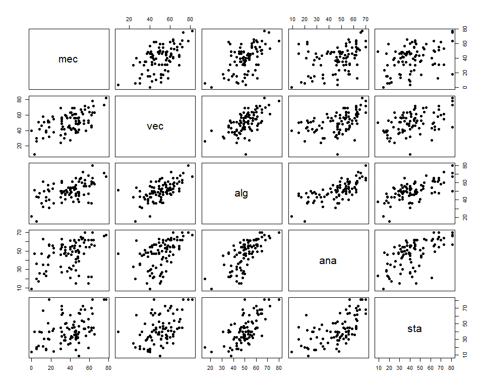

```r
library(boot)
library(bootstrap)
library(bootstrap);attach( scor )
pairs( scor, pch=19 )
```

Similarly, the sample correlation matrix is found via

```r
cor( scor )
```

```
##           mec       vec       alg       ana       sta
## mec 1.0000000 0.5534052 0.5467511 0.4093920 0.3890993
## vec 0.5534052 1.0000000 0.6096447 0.4850813 0.4364487
## alg 0.5467511 0.6096447 1.0000000 0.7108059 0.6647357
## ana 0.4093920 0.4850813 0.7108059 1.0000000 0.6071743
## sta 0.3890993 0.4364487 0.6647357 0.6071743 1.0000000
```

The plot and correlation matrix impart similar information: potentially strong positive correlations exist between most of the variable pairs. ‘Estimates’ of the various correlation are essentially the observed correlations fund in the correlation matrix, with ${\rho}_{12}$ = cor[vec,mec]

```r
B = 5000 #no. boostrap resamples
set.seed(76)
exc12.boot=boot( data=cbind(mec,vec),
 statistic=function(x,i){cor(x[i,1],x[i,2])}, R=B )
exc12.boot
```

```
##
## ORDINARY NONPARAMETRIC BOOTSTRAP
##
##
## Call:
## boot(data = cbind(mec, vec), statistic = function(x, i) {
##     cor(x[i, 1], x[i, 2])
## }, R = B)
##
##
## Bootstrap Statistics :
##      original       bias    std. error
## t1* 0.5534052 -0.004576231  0.07703896
```

where we see the ‘estimate’ is simply $\hat{\rho}_{12}$ = 0.5534, std error is 0.07703896,as in the correlation matrix. One could, however, use the information in the bootstrap distribution to ‘estimate’ ${\rho}_{12}$ as, say, the bootstrap mean

```r
mean( exc12.boot$t )
```

```
## [1] 0.5488289
```

or the bootstrap median

```r
median( exc12.boot$t )
```

```
## [1] 0.5538406
```

Similarly ${\rho}_{34}$ = cor[alg,ana]

```r
set.seed(76)
exc34.boot=boot( data=cbind(alg,ana),
 statistic=function(x,i){cor(x[i,1],x[i,2])}, R=B )
exc34.boot
```

```
##
## ORDINARY NONPARAMETRIC BOOTSTRAP
##
##
## Call:
## boot(data = cbind(alg, ana), statistic = function(x, i) {
##     cor(x[i, 1], x[i, 2])
## }, R = B)
##
##
## Bootstrap Statistics :
##      original        bias    std. error
## t1* 0.7108059 -0.0005011496  0.04773029
```

${\rho}_{35}$ = cor[alg,sta]

```r
set.seed(76)
exc35.boot=boot( data=cbind(alg,sta),
 statistic=function(x,i){cor(x[i,1],x[i,2])}, R=B )
exc35.boot
```

```
##
## ORDINARY NONPARAMETRIC BOOTSTRAP
##
##
## Call:
## boot(data = cbind(alg, sta), statistic = function(x, i) {
##     cor(x[i, 1], x[i, 2])
## }, R = B)
##
##
## Bootstrap Statistics :
##      original       bias    std. error
## t1* 0.6647357 -0.001585845  0.05927281
```

${\rho}_{45}$ = cor[ana,sta]

```r
set.seed(76)
exc45.boot=boot( data=cbind(ana,sta),
 statistic=function(x,i){cor(x[i,1],x[i,2])}, R=B )
exc45.boot
```

```
##
## ORDINARY NONPARAMETRIC BOOTSTRAP
##
##
## Call:
## boot(data = cbind(ana, sta), statistic = function(x, i) {
##     cor(x[i, 1], x[i, 2])
## }, R = B)
##
##
## Bootstrap Statistics :
##      original        bias    std. error
## t1* 0.6071743 -0.0006926977  0.06878724
```

### Question 2

- Repeat Project 7.A for the sample skewness statistic. Compare the coverage rates for normal populations (skewness 0) and $\chi^{2}(5)$ distributions (positive skewness)

### Answer 2

the skewness of the normal population is 0, and the skewness of $\chi^{2}(5)$ is $\sqrt{\frac{8}{5}}$.

```r
skewness <- function(x){
  #compute the sample skewness
  xbar <- mean(x)
  m3 <- mean((x-xbar)^3)
  m2 <- mean((x-xbar)^2)
  return( m3 / m2^1.5 )
}
```

### normal distribution

```r
library(boot)
set.seed(12345)
mu <- 0  # the skewness of normal populations
n <- 200  # the sample size in bootstrap
m <- 500 # replicate times
boot.skew <- function(x,i) skewness(x[i])
ci.norm <- ci.basic <- ci.perc <- matrix(NA,m,2)
for(i in 1:m){
  X <- rnorm(n,mean = 0,sd = 1)
  de <- boot(data = X, statistic = boot.skew, R = 1e3)
  ci <- boot.ci(de,type = c("norm","basic","perc"))
  ci.norm[i,] <- ci$norm[2:3]
  ci.basic[i,] <- ci$basic[4:5]
  ci.perc[i,] <- ci$percent[4:5]
}
cat('normal distribution missing on left:\n',
    'norm=',mean(ci.norm[,1]<=0),
    'basic=',mean(ci.basic[,1]<=0),
    'perc=',mean(ci.perc[,1]<=0),'\n'
    )
```

```
## normal distribution missing on left:
##  norm= 0.948 basic= 0.946 perc= 0.966
```

```r
cat('normal distribution missing in right:\n',
    'norm=',mean(ci.norm[,2]>=0),
    'basic=',mean(ci.basic[,2]>=0),
    'perc=',mean(ci.perc[,2]>=0),'\n'
    )
```

```
## normal distribution missing in right:
##  norm= 0.96 basic= 0.958 perc= 0.968
```

```r
cat('normal distribution cover.probability:\n','norm=',mean(ci.norm[,1]<= mu & ci.norm[,2]>= mu),
    'basic=',mean(ci.basic[,1]<= mu & ci.basic[,2]>= mu),'perc=',mean(ci.perc[,1]<= mu & ci.perc[,2]>= mu))
```

```
## normal distribution cover.probability:
##  norm= 0.908 basic= 0.904 perc= 0.934
```

### chi-square distribution

```r
library(boot)
set.seed(12345)
mu <- sqrt(8/5)  # the skewness of chi-squared distribution
n <- 200  # the sample size in bootstrap
m <- 500 # replicate times
boot.skew <- function(x,i) skewness(x[i])
ci.norm <- ci.basic <- ci.perc <- matrix(NA,m,2)
for(i in 1:m){
  X <- rchisq(n,df = 5)
  de <- boot(data = X, statistic = boot.skew, R = 1e3)
  ci <- boot.ci(de,type = c("norm","basic","perc"))
  ci.norm[i,] <- ci$norm[2:3]
  ci.basic[i,] <- ci$basic[4:5]
  ci.perc[i,] <- ci$percent[4:5]
}
cat('chi-square distribution missing on left:\n',
    'norm=',mean(ci.norm[,1]<=mu),
    'basic=',mean(ci.basic[,1]<=mu),
    'perc=',mean(ci.perc[,1]<=mu),'\n'
    )
```

```
## chi-square distribution missing on left:
##  norm= 0.98 basic= 0.97 perc= 0.994
```

```r
cat('chi-square distribution missing in right:\n',
    'norm=',mean(ci.norm[,2]>=mu),
    'basic=',mean(ci.basic[,2]>=mu),
    'perc=',mean(ci.perc[,2]>=mu),'\n'
    )
```

```
## chi-square distribution missing in right:
##  norm= 0.858 basic= 0.856 perc= 0.828
```

```r
cat('chi-square cover.probability:\n','norm=',mean(ci.norm[,1]<= mu & ci.norm[,2]>= mu),
    'basic=',mean(ci.basic[,1]<= mu & ci.basic[,2]>= mu),'perc=',mean(ci.perc[,1]<= mu & ci.perc[,2]>= mu))
```

```
## chi-square cover.probability:
##  norm= 0.838 basic= 0.826 perc= 0.822
```

## HW7:2019-11-15

### Question 1

- Refer to Exercise 7.7. Obtain the jackknife estimates of bias and standard error of $\hat{\theta}$.

### Answer 1

We continue here with the test score data from Exercise 7.6. The textbook does not specify the actual likelihood for these data, so instead of the MLE for the true covariance matrix $\sum$, we find the sample covariance matrix $\hat{\sum}$ from Exercise 7.6. To find its eigenvalues,$\lambda_{\mathrm{i}}$, start with

```r
library(boot)
library(bootstrap)
library(bootstrap);attach( scor )
cov( scor)
```

```
##          mec       vec       alg       ana       sta
## mec 305.7680 127.22257 101.57941 106.27273 117.40491
## vec 127.2226 172.84222  85.15726  94.67294  99.01202
## alg 101.5794  85.15726 112.88597 112.11338 121.87056
## ana 106.2727  94.67294 112.11338 220.38036 155.53553
## sta 117.4049  99.01202 121.87056 155.53553 297.75536
```

Continuing with the test score data from Exercise 7.6, to find jackknife estimates of bias and std. error,

First,instead of the loop,we define the core function, apply the eigen() function,The estimate of (proportion of variance)$\theta=\lambda_{1} / \Sigma \lambda_{i}$is calculated

```r
require(bootstrap);attach( scor )
 theta = function(x){
   eigen(cov(x))$values[1]/sum(eigen(cov(x))$values)
   }   #end function
```

Sample R code to complete the jackknife calculations is

```r
n = length( scor[,1] )
x = as.matrix(scor)
theta.jack = numeric( n )
theta.hat=theta(scor)
for (i in 1:n) { theta.jack[i] = theta( x[-i,] ) }
bias.jack = (n-1)*( mean(theta.jack) - theta.hat )
theta.bar = mean(theta.jack)
se.jack = sqrt( (n-1)*mean( (theta.jack-theta.bar)^2 ) )
print( list(theta.hat=theta(scor), bias=bias.jack, se=se.jack) )
```

```
## $theta.hat
## [1] 0.619115
##
## $bias
## [1] 0.001069139
##
## $se
## [1] 0.04955231
```

```r
detach(package:bootstrap)
```

so $\hat{bias}_{jack}(\hat{\theta})$=0.0011,and $\hat{se}_{jack}(\hat{\theta})$=0.04955

### Question 2

- In Example 7.18, leave-one-out (n-fold) cross validation was used to select the best fitting model. Repeat the analysis replacing the Log-Log model with a cubic polynomial model. Which of the four models is selected by the cross validation procedure? Which model is selected according to maximum adjusted $R^{2}$?

### Answer 2

For the iron-slag data from Example 7.18, sample R code for performing crossvalidation on the new *cubic model* $\mathrm{Y}=\beta_{0}+\beta_{1} \mathrm{X}+\beta_{2} \mathrm{X}^{2}+\beta_{0} \mathrm{X}^{3}+\varepsilon$, mimics that given in that Example

```r
library(DAAG); attach(ironslag)
n = length( magnetic )
e5 = numeric( n )
for (k in 1:n) {
  y = magnetic[-k]
  x = chemical[-k]
  J5 = lm(y ~ x + I(x^2) + I(x^3))
  e5[k] = magnetic[k]-predict( J5, newdata=data.frame(x=chemical[k]) )
  }   #end for loop  mean(e5^2)
 mean(e5^2)
```

```
## [1] 18.17756
```

This gives the MPSE for the *cubic model* as 18.17756

which is larger than the MSPE for the *quadratic model* (17.85248) see in the Example. The *quadratic model* remains the best of the candidate group.

```r
library(knitr)
library(kableExtra)
n <- length(magnetic) #in DAAG ironslag
e1 <- e2 <- e3 <- e4 <- numeric(n)
for (k in 1:n) {
  y <- magnetic[-k]
  x <- chemical[-k]

  J1 <- lm(y ~ x)
  yhat1 <- J1$coef[1] + J1$coef[2] * chemical[k]
  e1[k] <- magnetic[k] - yhat1

  J2 <- lm(y ~ x + I(x^2))
  yhat2 <- J2$coef[1] + J2$coef[2] * chemical[k] + J2$coef[3] * chemical[k]^2
  e2[k] <- magnetic[k] - yhat2

  J3 <- lm(log(y) ~ x)
  logyhat3 <- J3$coef[1] + J3$coef[2] * chemical[k]
  yhat3 <- exp(logyhat3)
  e3[k] <- magnetic[k] - yhat3

  J4 <- lm(log(y) ~ log(x))
  logyhat4 <- J4$coef[1] + J4$coef[2] * log(chemical[k])
  yhat4 <- exp(logyhat4)
  e4[k] <- magnetic[k] - yhat4
}
df<-data.frame('model'=c( 'Linear: Y = β0 + β1X + ε',' Quadratic: Y = β0 + β1X + β2X2 + ε' ,' Exponential: log(Y ) = log(β0)+β1X + ε',' Log-Log: log(Y )=β0 + β1 log(X)+ε',' new cubic model :Y = β0 + β1X + β2X2 + β0X3 + ε'),' prediction error '= c(mean(e1^2), mean(e2^2), mean(e3^2), mean(e4^2), mean(e5^2)))
kable(df) %>%
  kable_styling("striped",full_width = F) %>%
  column_spec(1, bold = T, border_right = T)
```

| model | X.prediction.error. |
| --- | --- |
| Linear: Y = β0 + β1X + ε | 19.55644 |
| Quadratic: Y = β0 + β1X + β2X2 + ε | 17.85248 |
| Exponential: log(Y ) = log(β0)+β1X + ε | 18.44188 |
| Log-Log: log(Y )=β0 + β1 log(X)+ε | 20.45424 |
| new cubic model :Y = β0 + β1X + β2X2 + β0X3 + ε | 18.17756 |

To compare these results with another model selection criterion such as maximizing the adjusted coefficient of determination, $R^2_{adj}$

```r
y = magnetic
x = chemical
 L1 = lm( y ~ x )
 L2 = lm( y ~ x + I(x^2) )
 L3 = lm( log(y) ~ x )
 L5 = lm( y ~ x + I(x^2) + I(x^3 ))
dt<-data.frame('model'=c('Linear: Y = β0 + β1X + ε',' Quadratic: Y = β0 + β1X + β2X2 + ε' ,' Exponential: log(Y ) = log(β0)+β1X + ε',' new cubic model :Y = β0 + β1X + β2X2 + β0X3 + ε'),
'R^2 adj'=c(summary(L1)$adj.r.squared, summary(L2)$adj.r.squared,             summary(L3)$adj.r.squared, summary(L5)$adj.r.squared))
kable(dt) %>%
  kable_styling("striped",full_width = F) %>%
  column_spec(1, bold = T, border_right = T)
```

| model | R.2.adj |
| --- | --- |
| Linear: Y = β0 + β1X + ε | 0.5281545 |
| Quadratic: Y = β0 + β1X + β2X2 + ε | 0.5768151 |
| Exponential: log(Y ) = log(β0)+β1X + ε | 0.5280556 |
| new cubic model :Y = β0 + β1X + β2X2 + β0X3 + ε | 0.5740396 |

from which we see the *quadratic model* has the highest$R^2_{adj}$ and would again be preferred.

```r
L5
```

```
##
## Call:
## lm(formula = y ~ x + I(x^2) + I(x^3))
##
## Coefficients:
## (Intercept)            x       I(x^2)       I(x^3)
##    3.015851     1.918082    -0.107963     0.002551
```

## HW8:2019-11-22

### Question 1

The Count 5 test for equal variances in Section 6.4 is based on the maximum number of extreme points. Example 6.15 shows that the Count 5 criterion is not applicable for unequal sample sizes. Implement a permutation test for equal variance based on the maximum number of extreme points that applies when sample sizes are not necessarily equal.

### Answer 1

```r
library(latticeExtra)
```

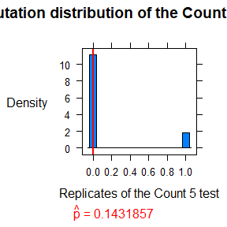

```r
## Dataset
n_1 <- 20 # Defining the sample sizes
n_2 <- 30
x <- rnorm(n_1, 0, 5)
y <- rnorm(n_2, 0, 5)

## function: permutation test for equal variance based
##           on the maximum number of extreme points
count5 <- function(x, y) {
  count5test <- function(x, y) { # Test statistic
    X <- x - mean(x)
    Y <- y - mean(y)
    outx <- sum(X > max(Y)) + sum(X < min(Y))
    outy <- sum(Y > max(X)) + sum(Y < min(X))
    # Return 1 (reject) or 0 (do not reject H_{0})
    return( as.integer( max(c(outx, outy) ) > 5) )
  }
  r <- 10000 # Permutation samples
  z <- c(x, y)
  n <- length(z)
  reps <- vector("numeric", r)
  t0 <- count5test(x, y)
  for (i in 1:r){ # Permutation test
    k = sample(n, size = length(x), replace = FALSE)
    reps[i] = count5test(z[k], z[-k])
  }
  p <-
    ifelse(t0 == 0, mean( c(t0, reps) > t0 ), mean( c(t0, reps) >= t0 ))
  return(
    histogram(c(t0, reps) # Histogram
              , type = "density"
              , col = "#0080ff"
              , xlab = "Replicates of the Count 5 test"
              , ylab = list(rot = 0)
              , main = "Permutation distribution of the Count 5 test"
              , sub = list(substitute(paste(hat(p), " = ",pvalue)
                                      , list(pvalue = p))
                           , col = 2)
              , panel = function(...){
                panel.histogram(...)
                panel.abline(v = t0, col = 2, lwd = 2)
              })
  )
}
count5(x, y)
```

### Question 2

Power comparison (distance correlation test versus ball covariance test)

Model 1:$Y=X/4+e$

Model 2:$Y=X/4×e$

$I∼N(0_2,I_2),e∼N(0_2,I_2)$, $X$ and $e$ are independent.

## HW9:2019-11-29

### Question

Implement a random walk Metropolis sampler for generating the standard Laplace distribution (see Exercise 3.2). For the increment, simulate from a normal distribution. Compare the chains generated when different variances are used for the proposal distribution. Also, compute the acceptance rates of each chain.

### Answer

The standard Laplace p.d.f. is $f(\mathrm{x})=-\frac{1}{2} \exp \{-|\mathrm{x}|\}$. Sample R code for a random walk Metropolis sampler, using $\mathrm{Y} \sim \mathrm{N}\left(\mathrm{X}_{t}, \sigma^{2}\right)$ for the proposal p.d.f. to produce the ‘random walk’ feature, is

```r
f <- function( x ) { -.5*exp(-abs(x)) }
set.seed(123)
 rw.MetropolisL <- function(sigma, x0, m) {
   x <- numeric(m)
   x[1] <- x0
   u <- runif(m)
   k <- 0
   for (i in 2:m) {
     y <- rnorm(1, x[i-1], sigma)
     if (u[i] <= (f(y) / f(x[i-1])))
       x[i] <- y
     else {
       x[i] <- x[i-1]
       k <- k + 1                 }
     }
     #end for loop
     return(list(x=x, k=k))}
   #end function
```

Mimicking the approach in Example 9.3, set m = 2000 and vary $\sigma$ over 0.05, 0.50, 2.0, 16.0. Use an arbitrary initial point of X0 = 25. Then, find the corresponding four chains

```r
library(kableExtra)
library(knitr)
 m <- 2000
sigma <- c(.05, .5, 2,  16)
x0 <- 25
rw1 <- rw.MetropolisL(sigma[1], x0, m)
rw2 <- rw.MetropolisL(sigma[2], x0, m)
rw3 <- rw.MetropolisL(sigma[3], x0, m)
rw4 <- rw.MetropolisL(sigma[4], x0, m)

#number of candidate points rejected
    no.reject <- data.frame(sigma=sigma,no.reject=c(rw1$k, rw2$k, rw3$k, rw4$k),accept = 1-c(rw1$k/m, rw2$k/m, rw3$k/m, rw4$k/m))
    kable(no.reject) %>%
  kable_styling("striped", full_width = F)
```

| sigma | no.reject | accept |
| --- | --- | --- |
| 0.05 | 32 | 0.9840 |
| 0.50 | 337 | 0.8315 |
| 2.00 | 944 | 0.5280 |
| 16.00 | 1810 | 0.0950 |

which are clearly quite disparate. The raw trace plots (without burn-in) are generated via

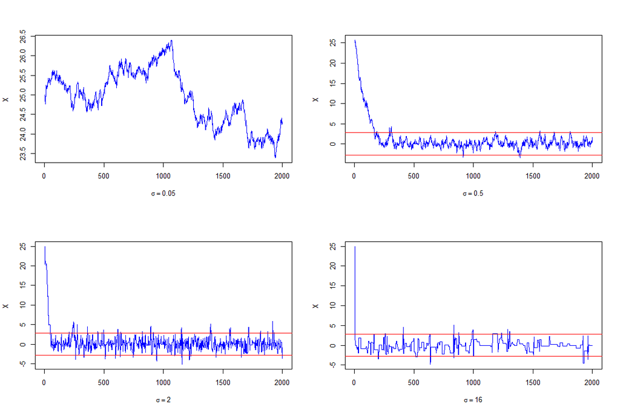

```r
par(mfrow=c(2,2))                #display 4 graphs together
rw <- cbind(rw1$x, rw2$x, rw3$x,  rw4$x)
refline <- qt(c(.025, .975), df=4)
for (j in 1:4) {
  plot(rw[,j], type="l", xlab=bquote(sigma == .(round(sigma[j],3))),              ylab="X", ylim=range(rw[,j]),col='blue')
    abline(h=refline,col='red')
  }#end for loop
```

The effect is similar to that seen in Figure 9.3 of Example 9.3; the standard Laplace p.d.f. has median at x = 0 and varies symmetrically from that point. We see the chain settles around x = 0 and also varies symmetrically about it, as seen best when $\sigma$ = 2.

## HW10:2019-12-6

### Question 1

The natural logarithm and exponential functions are inverses of each other,so that mathematically log(exp x) = exp(log x) = x. Show by example thatthis property does not hold exactly in computer arithmetic. Does the identityhold with near equality? (See all.equal.)

### Answer 1

Mathematically, log(ex) = x = elog(x). But in R, things can get tricky:

```r
x = seq(0.5, 5, 0.5)
cbind(x, log(exp(x))-exp(log(x)), log(exp(x))==exp(log(x)) )
```

```
##         x
##  [1,] 0.5  0.000000e+00 1
##  [2,] 1.0  0.000000e+00 1
##  [3,] 1.5  0.000000e+00 1
##  [4,] 2.0  0.000000e+00 1
##  [5,] 2.5  0.000000e+00 1
##  [6,] 3.0 -4.440892e-16 0
##  [7,] 3.5  0.000000e+00 1
##  [8,] 4.0  0.000000e+00 1
##  [9,] 4.5  0.000000e+00 1
## [10,] 5.0  8.881784e-16 0
```

We expect the second column to be all zeroes (but clearly it isn’t). Similarly, the last column should be all ones

```r
identical(log(exp(x)),exp(log(x)))
```

```
## [1] FALSE
```

while,

```r
all.equal(log(exp(x)),exp(log(x)))
```

```
## [1] TRUE
```

The all.equal command apparently allows for some computer-algebra ‘bleed’ unavailable in identical.

### Question 2

### Answer 2

First, we simplify the equation

```r
f<-function(a,k){
  g<-2*exp(lgamma((k+1)/2)-lgamma((k)/2))/sqrt(pi*k)
  ck<-sqrt((k*a^2)/(k+1-a^2))
  return(g*integrate(function(u){(1+u^2/k)^(-(k+1)/2)},lower = 0,upper = ck,rel.tol=.Machine$double.eps^0.25)$value)
}
g<-function(a,k){
  return(f(a,k)-f(a,k+1))
}
```

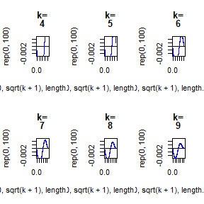

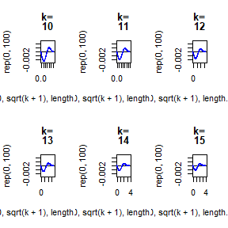

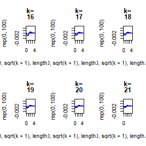

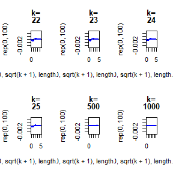

```r
par(mfrow=c(2,3))
for (k in c(4:25,500,1000)) {
  plot(seq(0,sqrt(k+1),length.out = 100),rep(0,100),type = 'l',ylim = c(-2.5e-3,2.5e-3),main = c('k=',k))
  for (a in seq(0,sqrt(k+1),by=0.01)) {
  points(a,g(a,k),pch=1,cex=0.1,col='blue')
}
}
```

we notice the followings

1. the Function is symmetrical about y-axis ,so we only need to find the zero point when a>0
2. because the function ->0 when k-> inf ,so we only need to find the first zero point
3. As k becomes larger, the zero point gradually changes,but not larger than 2

```r
ks<-c(4:25,500,1000)
cat(c('k','root','\n'))
```

```
## k root
```

```r
for(i in 1:length(ks)){
   cat( c( ks[i], uniroot(g, lower=0.0001, upper=2, k=ks[i])$root,'\n' ) )
}
```

```
## 4 1.53355644968259
## 5 1.56274408078203
## 6 1.58443009135651
## 7 1.60118472943817
## 8 1.61452135995119
## 9 1.62539016842908
## 10 1.63441857579205
## 11 1.6420377554804
## 12 1.64855387360045
## 13 1.65419036148543
## 14 1.65911410718533
## 15 1.66345228387817
## 16 1.66730350328525
## 17 1.67074540904529
## 18 1.67383996937294
## 19 1.67663724328696
## 20 1.67917811066874
## 21 1.68149628410631
## 22 1.68361981389982
## 23 1.68557222884593
## 24 1.68737341223481
## 25 1.68904028145466
## 500 1.72976002640128
## 1000 1.73091091645607
```

To compare,we sovle the exercise 11.4 too.

```r
k = c( 4:25, 500, 1000 )
cat(c('k','root','\n'))
```

```
## k root
```

```r
 object = function( a, df ){
   a2 = a^2
   arg = sqrt( a2*df/(df + 1 - a2) )
   Sk = pt( q=arg, df=df, lower=F)
   arg = sqrt( a2*(df-1)/(df - a2) )
   Skm1 = pt( q=arg, df=df-1, lower=F)
   return( Sk-Skm1 )
   }
 for ( i in 1:length(k) )  {
   cat( c( k[i], uniroot(object, lower=1, upper=2, df=k[i])$root ,'\n') )                           }
```

```
## 4 1.49210287247348
## 5 1.53355647503048
## 6 1.56274382154152
## 7 1.58443008801506
## 8 1.60118472195292
## 9 1.61452134821109
## 10 1.62539015295482
## 11 1.63441855729249
## 12 1.64203773464196
## 13 1.64855385101209
## 14 1.65419033762418
## 15 1.65911408242538
## 16 1.66345225851237
## 17 1.66730347753071
## 18 1.67074538307817
## 19 1.67383994331665
## 20 1.67663721723929
## 21 1.67917808469857
## 22 1.68149625828665
## 23 1.6836197882374
## 24 1.68557220340397
## 25 1.68737338701543
## 500 1.72975547089003
## 1000 1.73090748390211
```

```r
cat(c('k','difference','\n'))
```

```
## k difference
```

```r
 for ( i in 1:length(k) )  {
   cat( c( k[i], uniroot(object, lower=1, upper=2, df=k[i])$root-uniroot(g, lower=0.0001, upper=2, k=ks[i])$root,'\n') ) }
```

```
## 4 -0.041453577209108
## 5 -0.0291876057515523
## 6 -0.0216862698149838
## 7 -0.0167546414231057
## 8 -0.0133366379982751
## 9 -0.0108688202179852
## 10 -0.00902842283722904
## 11 -0.00761919818791279
## 12 -0.0065161389584818
## 13 -0.00563651047334335
## 14 -0.00492376956115215
## 15 -0.00433820145279262
## 16 -0.00385124477287779
## 17 -0.00344193151458083
## 18 -0.00309458629476378
## 19 -0.00279729997031097
## 20 -0.00254089342944797
## 21 -0.00231819940773748
## 22 -0.00212355561317268
## 23 -0.00195244060852762
## 24 -0.00180120883083679
## 25 -0.0016668944392273
## 500 -4.55551124933784e-06
## 1000 -3.43255396129116e-06
```

we could see that the difference is very small, nearly the same.diference is one is discrete form,the other one is continuous form.

### Question 3

### Answer 3

We use two methods as fllowings.

#### The E-M Algorithm

```r
library(kableExtra)
library(knitr)
df<-data.frame('Phenotype'=c('O','A','B','AB'),'Probability'=c('r^2','p^2+2pr','q^2+2qr','2pq'))
kable(df) %>%
  kable_styling(full_width = F) %>%
  column_spec(1, bold = T, border_right = T,width = '10em') %>%
  column_spec(2, width = "10em",bold = T)
```

| Phenotype | Probability |
| --- | --- |
| O | r^2 |
| A | p^2+2pr |
| B | q^2+2qr |
| AB | 2pq |

Defining the log-Likelihood function $-l(p, q, r)=-\left[2 n_{O} \ln r+n_{A} \ln \left(p^{2}+2 p r\right)+n_{B} \ln \left(q^{2}+2 q r\right)+n_{A B} \ln (2 p q)\right]$ For simplicity, we will ignore the multinomial constant. Here is what the likelihood function might look like:

```r
lnL <- function(p, q, nA = 28, nB = 24, nAB = 70, nO = 41) {

   r = 1.0 - p - q

   nA * log(p^2 + 2*p*r) + nB * log(q^2 + 2 * q * r) +
        nAB * log(2 * p * q) + 2 * nO * log(r)

}
```

The first approach we will try to likelihood maximization is the E-M algorithm. To do so we will estimate the number of individuals carrying each possible genotype based on the observed counts for each phenotype and estimates of the allele frequencies at each iteration.

```r
EM <- function (p, q, nA = 28, nB = 24, nAB = 70, nO = 41, debug = TRUE) {

    # Evaluate the likelihood using initial estimates
    llk <- lnL(p, q, nA, nB, nAB, nO)

    # Count the number of iterations so far
    iter <- 1

    # Loop until convergence ...
    while (TRUE)
       {
       # Estimate the frequency for allele O
       r = 1.0 - p - q

       # First we carry out the E-step

       # The counts for genotypes O/O and A/B are effectively observed
       # Estimate the counts for the other genotypes
       nAA <- nA * p / (p + 2*r)
       nAO <- nA - nAA
       nBB <- nB * q / (q + 2*r)
       nBO <- nB - nBB

       # Print debugging information
       if (debug)
          {
          cat("Round #", iter, "lnLikelihood = ", llk, "\n")
          cat("    Allele frequencies: p = ", p, ", q = ", q, ", r = ", r, "\n")
          cat("    Genotype counts:    nAA = ", nAA, ", nAO = ", nAO, ", nBB = ", nBB,
              ", nBO = ", nBO, "\n")
          }
       # Then the M-step
       p <- (2 * nAA + nAO + nAB) / (2 * (nA + nB + nO + nAB))
       q <- (2 * nBB + nBO + nAB) / (2 * (nA + nB + nO + nAB))

       # Then check for convergence ...
       llk1 <- lnL(p, q, nA, nB, nAB, nO)

       if (abs(llk1 - llk) < (abs(llk) + abs(llk1)) * 1e-6) break

       # Otherwise keep going
       llk <- llk1
       iter <- iter + 1
       }

  list(p = p, q = q)
}
EM(0.4,0.4)
```

```
## Round # 1 lnLikelihood =  -270.9849
##     Allele frequencies: p =  0.4 , q =  0.4 , r =  0.2
##     Genotype counts:    nAA =  14 , nAO =  14 , nBB =  12 , nBO =  12
## Round # 2 lnLikelihood =  -252.5037
##     Allele frequencies: p =  0.3435583 , q =  0.3251534 , r =  0.3312883
##     Genotype counts:    nAA =  9.560976 , nAO =  18.43902 , nBB =  7.900621 , nBO =  16.09938
## Round # 3 lnLikelihood =  -251.9282
##     Allele frequencies: p =  0.3299416 , q =  0.3125786 , r =  0.3574798
##     Genotype counts:    nAA =  8.841378 , nAO =  19.15862 , nBB =  7.300835 , nBO =  16.69917
## Round # 4 lnLikelihood =  -251.9148
##     Allele frequencies: p =  0.3277343 , q =  0.3107388 , r =  0.361527
##     Genotype counts:    nAA =  8.733025 , nAO =  19.26697 , nBB =  7.213952 , nBO =  16.78605
```

```
## $p
## [1] 0.3274019
##
## $q
## [1] 0.3104722
```

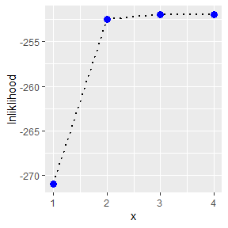

```r
library(ggplot2)
df<-data.frame('x'<-c(1,2,3,4),'lnliklihood'<-c( -270.9849 ,-252.5037,-251.9282,-251.9148))
ggplot(data = df,aes(x=x,y=lnliklihood))+geom_point(aes(y=lnliklihood),col='blue')+geom_line(linetype = 3,aes(y = lnliklihood),size = 0.8) +
  geom_point(aes(y = lnliklihood),size = 3,col='blue')
```

#### Methods Based on Scoring

Although matrix inversions can make these methods quite to tedious to carry out by hand, they are a breeze in R. The R functions D, **deriv** and **deriv3** allow derivatives to be calculated analytically for simple functions. They can also be used to calculate the **Hessian matrix** of second derivatives.

In this case, we will first use **deriv3** to construct a function that will evaluate our likelihood, its gradient and matrix of second derivatives at an arbitrary point.

```r
L <- deriv3(expression(
      nA * log(p^2 + 2*p*(1 - p - q)) + nB * log(q^2 + 2 * q * (1 - p - q)) +
      nAB * log(2 * p * q) + 2 * nO * log(1 - p - q)), c("p", "q"),
      function (p, q, nA = 28, nB = 24, nAB = 70, nO = 41) { } )
```

We can now use this information to construct a simple algorithm based on Newton’s method

```r
Newton <- function(p, q, nA = 28, nB = 24, nAB = 70, nO = 41, debug = TRUE) {

   # Calculate likelihood, score and information
   pointEstimates <- L(p, q, nA, nB, nAB, nO)

   iter <- 1

   while (TRUE) {

       llk <- pointEstimates[1]
       S <- attr(pointEstimates, "gradient") [1,]
       I <- -attr(pointEstimates, "hessian") [1,,]

       # Print debugging information
       if (debug)
          {
          cat("Round #", iter, "lnLikelihood = ", llk, "\n")
          cat("    Allele frequencies: p = ", p, ", q = ", q, ", r = ", 1-p-q, "\n")
          cat("    Score: ", S, "\n")
          }

       # Update point
       delta <- solve(I, S)

       p <- p + delta[1]
       q <- q + delta[2]

       # Calculate likelihood, score and information
       pointEstimates <- L(p, q, nA, nB, nAB, nO)
       llk1 <- pointEstimates[1]

       # Check for convergence
       if (abs(llk1 - llk) < (abs(llk) + abs(llk1)) * 1e-6) break

       # Keep going
       iter <- iter + 1
       }

    list(p = p, q = q)
}
Newton(0.4,0.4)
```

```
## Round # 1 lnLikelihood =  -270.9849
##     Allele frequencies: p =  0.4 , q =  0.4 , r =  0.2
##     Score:  -260 -275
## Round # 2 lnLikelihood =  -253.9346
##     Allele frequencies: p =  0.3591507 , q =  0.3352208 , r =  0.3056286
##     Score:  -75.00171 -70.95215
## Round # 3 lnLikelihood =  -251.927
##     Allele frequencies: p =  0.3293071 , q =  0.3129746 , r =  0.3577183
##     Score:  -5.11091 -5.825382
## Round # 4 lnLikelihood =  -251.9145
##     Allele frequencies: p =  0.3273592 , q =  0.3104315 , r =  0.3622093
##     Score:  -0.02823343 -0.01901306
```

```
## $p
##         p
## 0.3273442
##
## $q
##         q
## 0.3104267
```

## HW11:2019-12-13

### P204 3,4,5

- **Use both for loops and `lapply()` to fit linear models to the `mtcars` using the formulas stored in this lists:**

```r
formulas <-list(mpg ~ disp,mpg ~I(1/ disp),mpg ~ disp + wt,mpg ~I(1/ disp) + wt)
```

#### loop

```r
res<-list()
for(i in 1:length(formulas)){
  res[[i]]<-lm(formulas[[i]], data=mtcars)
  }
res
```

```
## [[1]]
##
## Call:
## lm(formula = formulas[[i]], data = mtcars)
##
## Coefficients:
## (Intercept)         disp
##    29.59985     -0.04122
##
##
## [[2]]
##
## Call:
## lm(formula = formulas[[i]], data = mtcars)
##
## Coefficients:
## (Intercept)    I(1/disp)
##       10.75      1557.67
##
##
## [[3]]
##
## Call:
## lm(formula = formulas[[i]], data = mtcars)
##
## Coefficients:
## (Intercept)         disp           wt
##    34.96055     -0.01772     -3.35083
##
##
## [[4]]
##
## Call:
## lm(formula = formulas[[i]], data = mtcars)
##
## Coefficients:
## (Intercept)    I(1/disp)           wt
##      19.024     1142.560       -1.798
```

#### lapply

```r
lapply(formulas, FUN=function(x) lm(formula=x, data=mtcars))
```

```
## [[1]]
##
## Call:
## lm(formula = x, data = mtcars)
##
## Coefficients:
## (Intercept)         disp
##    29.59985     -0.04122
##
##
## [[2]]
##
## Call:
## lm(formula = x, data = mtcars)
##
## Coefficients:
## (Intercept)    I(1/disp)
##       10.75      1557.67
##
##
## [[3]]
##
## Call:
## lm(formula = x, data = mtcars)
##
## Coefficients:
## (Intercept)         disp           wt
##    34.96055     -0.01772     -3.35083
##
##
## [[4]]
##
## Call:
## lm(formula = x, data = mtcars)
##
## Coefficients:
## (Intercept)    I(1/disp)           wt
##      19.024     1142.560       -1.798
```

- **Fit the model `mpg ~ disp` to each of the bootstrap replicates of `mtcars` in the list below by using a for loop and `lapply()`. Can you do it without an anonymous function?**

```r
bootstraps <- lapply(1:10, function(i) {
  rows <- sample(1:nrow(mtcars), rep = TRUE)
  mtcars[rows, ]
})
```

#### loop

```r
res2<-list()
for(i in 1:length(bootstraps)){
  res2[[i]]<-lm(formula=mpg ~ disp, data=bootstraps[[i]])
}
res2
```

```
## [[1]]
##
## Call:
## lm(formula = mpg ~ disp, data = bootstraps[[i]])
##
## Coefficients:
## (Intercept)         disp
##    26.71768     -0.03241
##
##
## [[2]]
##
## Call:
## lm(formula = mpg ~ disp, data = bootstraps[[i]])
##
## Coefficients:
## (Intercept)         disp
##    29.78674     -0.04157
##
##
## [[3]]
##
## Call:
## lm(formula = mpg ~ disp, data = bootstraps[[i]])
##
## Coefficients:
## (Intercept)         disp
##    29.39332     -0.03905
##
##
## [[4]]
##
## Call:
## lm(formula = mpg ~ disp, data = bootstraps[[i]])
##
## Coefficients:
## (Intercept)         disp
##    27.81021     -0.03279
##
##
```

[output cut: 43 more lines]

```
## lm(formula = mpg ~ disp, data = bootstraps[[i]])
##
## Coefficients:
## (Intercept)         disp
##    26.73700     -0.03122
##
##
## [[10]]
##
## Call:
## lm(formula = mpg ~ disp, data = bootstraps[[i]])
##
## Coefficients:
## (Intercept)         disp
##    30.36659     -0.04073
```

#### lapply

```r
lapply(bootstraps, FUN=function(x) lm(mpg~disp, data=x))
```

```
## [[1]]
##
## Call:
## lm(formula = mpg ~ disp, data = x)
##
## Coefficients:
## (Intercept)         disp
##    26.71768     -0.03241
##
##
## [[2]]
##
## Call:
## lm(formula = mpg ~ disp, data = x)
##
## Coefficients:
## (Intercept)         disp
##    29.78674     -0.04157
##
##
## [[3]]
##
## Call:
## lm(formula = mpg ~ disp, data = x)
##
## Coefficients:
## (Intercept)         disp
##    29.39332     -0.03905
##
##
## [[4]]
##
## Call:
## lm(formula = mpg ~ disp, data = x)
##
## Coefficients:
## (Intercept)         disp
##    27.81021     -0.03279
##
##
```

[output cut: 43 more lines]

```
## lm(formula = mpg ~ disp, data = x)
##
## Coefficients:
## (Intercept)         disp
##    26.73700     -0.03122
##
##
## [[10]]
##
## Call:
## lm(formula = mpg ~ disp, data = x)
##
## Coefficients:
## (Intercept)         disp
##    30.36659     -0.04073
```

- **For each model in the previous two exercises, extract R^2 using the function below.**

```r
rsq <- function(mod) summary(mod)$r.squared
```

#### E3

```r
lapply(formulas, FUN=function(x) rsq(lm(formula=x, data=mtcars)))
```

```
## [[1]]
## [1] 0.7183433
##
## [[2]]
## [1] 0.8596865
##
## [[3]]
## [1] 0.7809306
##
## [[4]]
## [1] 0.8838038
```

#### E4

```r
lapply(bootstraps, FUN=function(x) rsq(lm(mpg~disp, data=x)))
```

```
## [[1]]
## [1] 0.8034013
##
## [[2]]
## [1] 0.7386716
##
## [[3]]
## [1] 0.6572146
##
## [[4]]
## [1] 0.6786082
##
## [[5]]
## [1] 0.7559773
##
## [[6]]
## [1] 0.7712581
##
## [[7]]
## [1] 0.6752694
##
## [[8]]
## [1] 0.6337313
##
## [[9]]
## [1] 0.6508021
##
## [[10]]
## [1] 0.7325716
```

### P214 3,7

- **The following code simulates the performance of a t-test for non-normal data. Use `sapply()` and an annoymous function to extract the p-value from every trial. Extra challenge: get rid of the anonymous function by using`[[` directly.**

```r
trials <- replicate(
  100,
  t.test(rpois(10, 10), rpois(7, 10)),
  simplify = FALSE
)
```

```r
sapply(trials,function(mod){mod[["p.value"]]},simplify=TRUE)
```

```
##   [1] 0.773249549 0.424026961 0.157638914 0.740470866 0.504804965 0.155602601
##   [7] 0.320895118 0.117459608 0.627610209 0.037672441 0.363252429 0.079380821
##  [13] 0.127081757 0.620357155 0.188887377 0.049020015 0.143655762 0.047327504
##  [19] 0.993828298 0.035354389 0.886073518 0.740260158 0.544953376 0.475565081
##  [25] 0.494718419 0.857926117 0.787525763 0.205288816 0.058695989 0.238326793
##  [31] 0.458172676 0.559245373 0.204320809 0.532646618 0.482126283 0.855213397
##  [37] 0.747673286 0.444118432 0.050643079 0.582451656 0.738666096 0.003189333
##  [43] 0.715496960 0.705477132 0.623964677 0.478859339 0.720813103 0.853587871
##  [49] 0.634761257 0.957636134 0.522593572 0.312985178 0.314317813 0.501265287
##  [55] 0.507617100 0.327461485 0.142185883 0.408838419 0.696673763 0.098932388
##  [61] 0.517156386 0.479654100 0.376619585 0.136657693 0.358186749 0.446961952
##  [67] 0.533363094 0.224294419 0.339562147 0.495134255 0.513022095 0.808470503
##  [73] 0.331822600 0.860354429 0.878566969 0.992768424 0.892893986 0.347161723
##  [79] 0.861159762 0.759097436 0.928913088 0.140474834 0.263926305 0.261179602
##  [85] 0.653702151 0.853353021 0.643144497 0.705452666 0.310024148 0.053270961
##  [91] 0.204620052 0.246292564 0.514136130 0.873719443 0.264267979 0.343492636
##  [97] 0.869559149 0.193103452 0.463704782 0.625104340
```

#### use ‘[[’

```r
sapply(trials, function(x) "[["(x,'p.value'))
```

```
##   [1] 0.773249549 0.424026961 0.157638914 0.740470866 0.504804965 0.155602601
##   [7] 0.320895118 0.117459608 0.627610209 0.037672441 0.363252429 0.079380821
##  [13] 0.127081757 0.620357155 0.188887377 0.049020015 0.143655762 0.047327504
##  [19] 0.993828298 0.035354389 0.886073518 0.740260158 0.544953376 0.475565081
##  [25] 0.494718419 0.857926117 0.787525763 0.205288816 0.058695989 0.238326793
##  [31] 0.458172676 0.559245373 0.204320809 0.532646618 0.482126283 0.855213397
##  [37] 0.747673286 0.444118432 0.050643079 0.582451656 0.738666096 0.003189333
##  [43] 0.715496960 0.705477132 0.623964677 0.478859339 0.720813103 0.853587871
##  [49] 0.634761257 0.957636134 0.522593572 0.312985178 0.314317813 0.501265287
##  [55] 0.507617100 0.327461485 0.142185883 0.408838419 0.696673763 0.098932388
##  [61] 0.517156386 0.479654100 0.376619585 0.136657693 0.358186749 0.446961952
##  [67] 0.533363094 0.224294419 0.339562147 0.495134255 0.513022095 0.808470503
##  [73] 0.331822600 0.860354429 0.878566969 0.992768424 0.892893986 0.347161723
##  [79] 0.861159762 0.759097436 0.928913088 0.140474834 0.263926305 0.261179602
##  [85] 0.653702151 0.853353021 0.643144497 0.705452666 0.310024148 0.053270961
##  [91] 0.204620052 0.246292564 0.514136130 0.873719443 0.264267979 0.343492636
##  [97] 0.869559149 0.193103452 0.463704782 0.625104340
```

- **Implement `mcsapply()`, a multicore version of `sapply()`. Can you implement `mcvapply`, a parallel version of vapply()? Why or why not?**

my intuition is that `mcvapply` is impossible, since it allocates the vector first and how can you do that with parallel? In the cheapest move ever, I implement sapply by taking the guts of sapply and changing lapply to mclapply:

#### mcsapply

```r
library(parallel)
library(parallelsugar) ## to fit in the Windows system
mcsapply <- function (X, FUN, ..., simplify = TRUE, USE.NAMES = TRUE)
  {
  FUN <- match.fun(FUN)
  answer <- mclapply(X = X, FUN = FUN, mc.cores = 2, ...)
  if (USE.NAMES && is.character(X) && is.null(names(answer)))
    names(answer) <- X
  if (!identical(simplify, FALSE) && length(answer))
    simplify2array(answer, higher = (simplify == "array"))
  else answer
}
```

#### mcvapply

```r
mcvapply <- function(x, f, FUN.VALUE, ...) {
    out_list <- mclapply(f, ...)
    out <- matrix(rep(FUN.VALUE, length(x)), nrow = length(x))
    for (i in seq_along(x)) {
        stopifnot(
            length(res) == length(f.value),
            typeof(res) == typeof(f.value))
        out[i, ] <- out_list[[i]]
    }
    out
}
```

## HW12:2019-12-20

#### Rewrite a Rcpp function

Firstly, we write a cppFunction

```r
library(Rcpp) # Attach R package "Rcpp"
    # Define function "rw_MetropolisL"
cppFunction('List rw_MetropolisL(double sigma, int x0, int m){
            NumericVector x(m);
            NumericVector u(m);
            as<DoubleVector>(x)[0] = x0;
            u = as<DoubleVector>(runif(m));
            int k = 0;
            int i;
            for(i=1;i<m;++i){
               double y = as<double>(rnorm(1,x[i-1],sigma));
               if(u[i] <= exp(-fabs(y)+abs(x[i-1]))){
               x[i] = y;
               }
               else{
               x[i] = x[i-1];
               k = k+1;
               }
            }
            List L=List::create(Named("x")=x, Named("k")=k);
            return L;
            }
            ')
```

With the original R Function

```r
f <- function( x ) { -.5*exp(-abs(x)) }
set.seed(123)
 rw.MetropolisL <- function(sigma, x0, m) {
   x <- numeric(m)
   x[1] <- x0
   u <- runif(m)
   k <- 0
   for (i in 2:m) {
     y <- rnorm(1, x[i-1], sigma)
     if (u[i] <= (f(y) / f(x[i-1])))
       x[i] <- y
     else {
       x[i] <- x[i-1]
       k <- k + 1                 }
     }
     #end for loop
     return(list(x=x, k=k))}
   #end function
```

```r
library(microbenchmark)
N <- 2000
sigma <- c(0.05,0.5,2,4,8,16)
x0 <- 25
for(i in 1:length(sigma)){
  assign(paste0("rw",i),rw.MetropolisL(sigma[i],x0,N))
  assign(paste0('rw_',i),rw_MetropolisL(sigma[i],x0,N))
  assign(paste0('ts',i) ,microbenchmark(meanR=rw.MetropolisL(sigma[i],x0,N),
                                         meancpp=rw_MetropolisL(sigma[i],x0,N)))
}
```

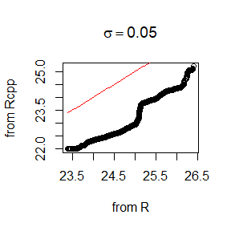

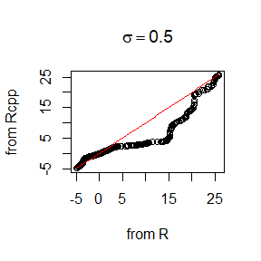

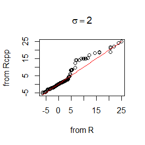

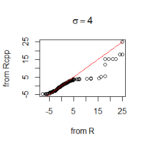

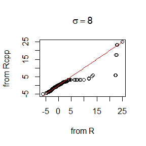

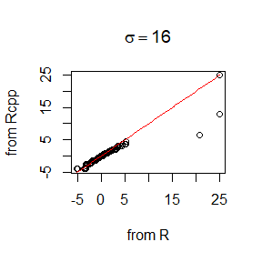

```r
for(i in 1:length(sigma)){

  qqplot(get(paste0("rw",i))$x,

         get(paste0("rw_",i))$x,

         xlab = "from R",ylab = "from Rcpp",

         main = bquote(sigma == .(sigma[i])))

  f <- function(x) x

  curve(f, col = 'red',add = TRUE)

}
```

```r
summary(ts1)[,c(1,3,5,6)]
```

```
##      expr      lq median      uq
## 1   meanR 5927.80 6316.6 6870.05
## 2 meancpp  309.95  323.2  338.00
```

```r
summary(ts2)[,c(1,3,5,6)]
```

```
##      expr     lq  median     uq
## 1   meanR 6062.2 6501.15 7289.2
## 2 meancpp  320.7  329.05  367.5
```

```r
summary(ts3)[,c(1,3,5,6)]
```

```
##      expr      lq median      uq
## 1   meanR 6302.45 6693.2 7820.45
## 2 meancpp  304.25  315.1  349.05
```

```r
summary(ts4)[,c(1,3,5,6)]
```

```
##      expr     lq  median      uq
## 1   meanR 6124.3 6498.20 7028.80
## 2 meancpp  290.1  299.85  321.05
```

```r
summary(ts5)[,c(1,3,5,6)]
```

```
##      expr      lq  median      uq
## 1   meanR 5911.75 6250.20 7110.10
## 2 meancpp  279.50  291.05  303.55
```

```r
summary(ts6)[,c(1,3,5,6)]
```

```
##      expr      lq  median      uq
## 1   meanR 6061.05 6356.65 6875.55
## 2 meancpp  278.15  287.90  305.40
```

**We can conclude that the Rcpp function implement the same work as the R function do, the acceptance rate from two chains is similar, but Rcpp function consume much less time.**